# <em>A priori</em> quality checks

RDBqc allows to carry out a set of *a priori* quality checks on detailed sampling data and on aggregated landing data, and *a posteriori* quality check on MEDBS, FDI and GFCM data call formats.

The supported quality checks in version 0.0.13 are:

### *A priori* quality checks

- RCG CS - biological sampling data
- RCG CL - aggregated landing data

### *A posteriori* quality checks

- MEDBS - catch data
- MEDBS - discard data
- MEDBS - landing data
- MEDBS - GP table
- MEDBS - LW table
- MEDBS - MA table
- MEDBS - ML table
- MEDBS - SA table
- MEDBS - SL table
- FDI tables (A, G, H, I and J)
- GFCM - Task II.2 table
- GFCM - Task III table
- GFCM - Task VII.2 table
- GFCM - Task VII.3.1 table
- GFCM - Task VII.3.2 table

# Checks on RCG

Example of Regional Coordination Group Mediterranean & Black Sea data formats:

**CS table**

```r
head(data_ex)
```

```
#>   Sampling_type Flag_country Year  Trip_code Harbour
#> 1             S          ITA 2016 01_18_2016   ITMOL
#> 2             S          ITA 2016 01_18_2016   ITMOL
#> 3             S          ITA 2016 01_18_2016   ITMOL
#> 4             S          ITA 2016 01_18_2016   ITMOL
#> 5             S          ITA 2016 01_18_2016   ITMOL
#> 6             S          ITA 2016 01_18_2016   ITMOL
#>   Number_of_sets_hauls_on_trip Days_at_sea Sampling_method Aggregation_level
#> 1                            4           1    SelfSampling              TRUE
#> 2                            4           1    SelfSampling              TRUE
#> 3                            4           1    SelfSampling              TRUE
#> 4                            4           1    SelfSampling              TRUE
#> 5                            4           1    SelfSampling              TRUE
#> 6                            4           1    SelfSampling              TRUE
#>   Station_number Duration_of_fishing_operation Initial_latitude
```

[output cut: 55 more lines]

**CL table**

```r
head(data_exampleCL)
```

```
#>   flag_country year quarter month  area                  species
#> 1     COUNTRY1 2014       1     1 GSA99 Parapenaeus longirostris
#> 2     COUNTRY1 2014       1     2 GSA99 Parapenaeus longirostris
#> 3     COUNTRY1 2014       1     3 GSA99 Parapenaeus longirostris
#> 4     COUNTRY1 2014       2     4 GSA99 Parapenaeus longirostris
#> 5     COUNTRY1 2014       2     5 GSA99 Parapenaeus longirostris
#> 6     COUNTRY1 2014       2     6 GSA99 Parapenaeus longirostris
#>   fishing_activity_category_national fishing_activity_category_eu_l6 harbour
#> 1                          OTB_shelf                OTB_DEF_>=40_0_0    Port
#> 2                          OTB_shelf                OTB_DEF_>=40_0_0    Port
#> 3                          OTB_shelf                OTB_DEF_>=40_0_0    Port
#> 4                          OTB_shelf                OTB_DEF_>=40_0_0    Port
#> 5                          OTB_shelf                OTB_DEF_>=40_0_0    Port
#> 6                          OTB_shelf                OTB_DEF_>=40_0_0    Port
#>   official_landings_weight official_landings_value
#> 1                 73452.53                372658.8
#> 2                 78741.52                392665.2
#> 3                 82021.10                460280.8
#> 4                 89022.59                433524.2
#> 5                103911.92                494103.4
#> 6                102987.30                498298.8
```

## Checks on CS

### check LFD

This function `RCG_check_LFD` returns an empty data frame if all the lengths collected are within the length range min_len-max_len; if some lengths are outside this range, the corresponding records are returned as a data frame.

```r
RCG_check_LFD(data_ex,MS="ITA",GSA="GSA99", SP="Mullus barbatus",min_len=6,max_len=250)[[1]]
```

```
#>      Flag_country Year  Trip_code       Date  Area Commercial_size_category Age
#> 1             ITA 2016 01_18_2016 18/02/2016 GSA99                        1  NA
#> 5544          ITA 2014  4_18_2014 04/07/2014 GSA99                        1   7
#>      Sex Length_class fish_ID
#> 1      F          500      NA
#> 5544   F          270      NA
```

A plot of the frequency distribution is also returned:

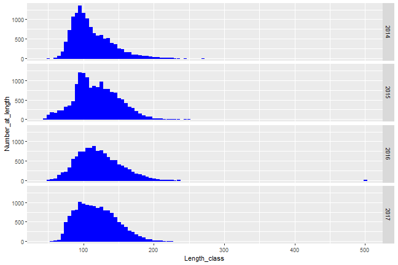

```r
RCG_check_LFD(data_ex,MS="ITA",GSA="GSA99", SP="Mullus barbatus",min_len=6,max_len=250)[[2]]
```

### check LFD by commercial categories

This function `RCG_check_LFD_comm_cat` reports for each year and commercial category the minimum and maximum lengths in the dataset.

```r
RCG_check_LFD_comm_cat(data_ex,MS="ITA",GSA="GSA99", SP="Mullus barbatus")[[1]]
```

```
#>    Year Commercial_size_category Min Max
#> 1  2014                        1  75 270
#> 2  2014                        2  60 205
#> 3  2014                        3  65 155
#> 4  2014                        S  50 130
#> 5  2015                        1  75 250
#> 6  2015                        2  45 195
#> 7  2015                        3  80 175
#> 8  2015                        S  45 140
#> 9  2016                        1  50 500
#> 10 2016                        2  70 190
#> 11 2016                        3  80 155
#> 12 2016                        S  50 130
#> 13 2017                        1  80 225
#> 14 2017                        2  70 205
#> 15 2017                        3  65 150
#> 16 2017                        S  55 130
```

A plot of the length distributions by year and commercial category is also returned:

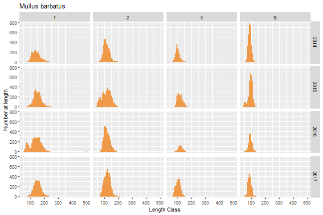

```r
RCG_check_LFD_comm_cat(data_ex,MS="ITA",GSA="GSA99", SP="Mullus barbatus")[[2]]
```

### Check AL

This function `RCG_check_AL` reports for each year and length class the number of age measurements in the dataset, providing a summary data frame.

```r
results <- RCG_check_AL(data_ex,MS="ITA",GSA="GSA99",SP="Mullus barbatus",min_age=0,max_age=5)[[1]]
```

```
#> NA included in the 'Age' field have been removed from the analysis.
```

```r
head(results)
```

```
#>   Year Length_class nb_age_measurements
#> 1 2014           50                   1
#> 2 2014           60                  11
#> 3 2014           65                  20
#> 4 2014           70                  20
#> 5 2014           75                  18
#> 6 2014           80                  18
```

Moreover, the function detects if the age data are in the range min_age-max_age, reporting the list of the trip codes including outliers.

```r
RCG_check_AL(data_ex,MS="ITA",GSA="GSA99",SP="Mullus barbatus",min_age=0,max_age=5)[[2]]
```

```
#> NA included in the 'Age' field have been removed from the analysis.
#>      Flag_country Year  Trip_code       Date  Area Commercial_size_category
#> 6             ITA 2016 01_18_2016 18/02/2016 GSA99                        1
#> 25            ITA 2016 01_18_2016 18/02/2016 GSA99                        1
#> 75            ITA 2016 02_18_2016 21/03/2016 GSA99                        1
#> 78            ITA 2016 02_18_2016 21/03/2016 GSA99                        1
#> 394           ITA 2015 05_18_2015 22/04/2015 GSA99                        1
#> 396           ITA 2015 05_18_2015 22/04/2015 GSA99                        1
#> 397           ITA 2015 05_18_2015 22/04/2015 GSA99                        1
#> 529           ITA 2016 07_18_2016 17/03/2016 GSA99                        1
#> 705           ITA 2016 08_18_2016 29/03/2016 GSA99                        1
#> 2455          ITA 2015 12_18_2015 24/05/2015 GSA99                        1
#> 4267          ITA 2014 17_18_2014 08/08/2014 GSA99                        1
#> 4269          ITA 2014 17_18_2014 08/08/2014 GSA99                        1
#> 5210          ITA 2017 31_18_2017 11/05/2017 GSA99                        1
```

[output cut: 22 more lines]

A plot of the age/length relationship by sex and year is outputted for the selected species

```r
RCG_check_AL(data_ex,MS="ITA",GSA="GSA99",SP="Mullus barbatus",min_age=0,max_age=5)[[3]]
```

```
#> NA included in the 'Age' field have been removed from the analysis.
```

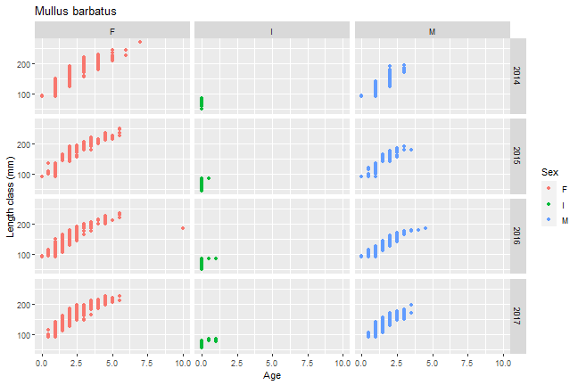

### Check lw

This function `RCG_check_lw` plots for each year and sex the length-weight scatter plot

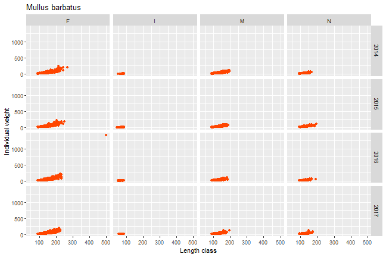

```r
RCG_check_lw(data_ex,MS="ITA",GSA="GSA99", SP="Mullus barbatus",Min=0,Max=200)[[2]]
```

Furthermore, it checks if the weight data are within the boundaries in input, providing the data frame of the records with the outliers

```r
RCG_check_lw(data_ex,MS="ITA",GSA="GSA99", SP="Mullus barbatus",Min=0,Max=200)[[1]]
```

```
#>      Flag_country Year  Trip_code       Date  Area Commercial_size_category Age
#> 1             ITA 2016 01_18_2016 18/02/2016 GSA99                        1  NA
#> 77            ITA 2016 02_18_2016 21/03/2016 GSA99                        1 4.5
#> 2430          ITA 2014 12_18_2014 24/07/2014 GSA99                        1 5.0
#> 5544          ITA 2014  4_18_2014 04/07/2014 GSA99                        1 7.0
#> 5777          ITA 2015 43_18_2015 31/07/2015 GSA99                        1 4.0
#> 7946          ITA 2014 87_18_2014 05/12/2014 GSA99                        1 4.0
#> 7949          ITA 2014 87_18_2014 05/12/2014 GSA99                        1 5.0
#>      Sex Length_class fish_ID
#> 1      F          500      NA
#> 77     F          225      NA
#> 2430   F          220      NA
#> 5544   F          270      NA
#> 5777   F          205      NA
#> 7946   F          215      NA
#> 7949   F          245      NA
```

### check maturity stages

This function `RCG_check_mat` plots for each year and sex the length-maturity stage scatter plot

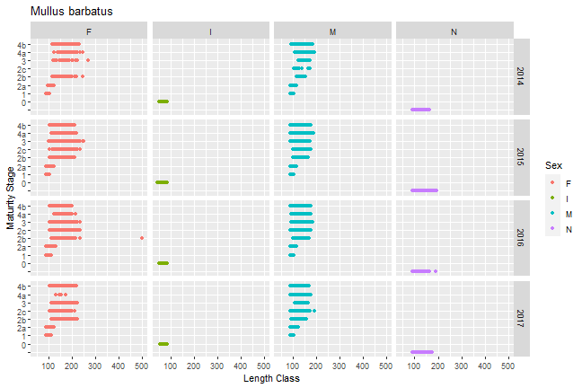

```r
RCG_check_mat(data_ex,MS="ITA",GSA="GSA99",SP="Mullus barbatus")
```

### check matutity ogive

This function `RCG_check_mat_ogive` plots the maturity ogive by sex derived from the dataset:

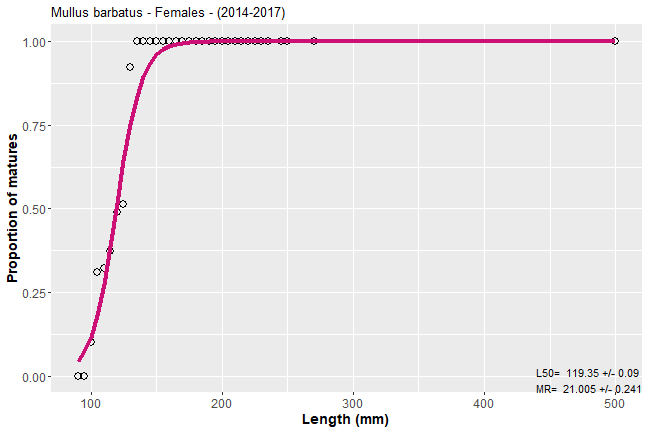

```r
RCG_check_mat_ogive(data_ex,MS="ITA",GSA="GSA99",SP="Mullus barbatus", sex="F",immature_stages=c("0","1","2a"))
```

### Summarize individual measurements

This function `RCG_summarize_ind_meas` reports for each trip the number of length sex, maturity, individual weight and age measurements for a selected species.

```r
results <- RCG_summarize_ind_meas(data=data_ex,MS="ITA",GSA="GSA99",SP="Mullus barbatus")
head(results)
```

```
#>   Year  Area         Species  Trip_code age_data length_measurements
#> 1 2014 GSA99 Mullus barbatus 12_18_2014       54                 120
#> 2 2014 GSA99 Mullus barbatus 14_18_2014       52                 163
#> 3 2014 GSA99 Mullus barbatus 15_18_2014       68                 252
#> 4 2014 GSA99 Mullus barbatus 17_18_2014       27                 239
#> 5 2014 GSA99 Mullus barbatus 19_18_2014       84                1657
#> 6 2014 GSA99 Mullus barbatus 20_18_2014       32                 752
#>   maturity_data sex_data weight_data
#> 1           120      120         120
#> 2           163      163         163
#> 3           252      252         252
#> 4           239      239         239
#> 5          1657     1657        1657
#> 6           752      752         752
```

### Summarize trips

This function `RCG_summarize_trips` reports for the selected species the number of trips in the dataset for each year, area, harbour, metier and sampling method.

```r
results <- RCG_summarize_trips(data_ex,MS="ITA",GSA="GSA99",SP="Mullus barbatus")
head(results)
```

```
#>   Year Flag_country  Area Harbour         Species
#> 1 2014          ITA GSA99   ITBCE Mullus barbatus
#> 2 2014          ITA GSA99   ITBDS Mullus barbatus
#> 3 2014          ITA GSA99   ITBDS Mullus barbatus
#> 4 2014          ITA GSA99   ITMFR Mullus barbatus
#> 5 2014          ITA GSA99   ITMFR Mullus barbatus
#> 6 2014          ITA GSA99   ITMNP Mullus barbatus
#>   Fishing_activity_category_European_lvl_6 Sampling_method Nb_trips
#> 1                         OTB_DEF_>=40_0_0        Observer        2
#> 2                         OTB_DEF_>=40_0_0        Observer        2
#> 3                         OTB_DEF_>=40_0_0    SelfSampling        2
#> 4                         OTB_DEF_>=40_0_0        Observer        1
#> 5                         OTB_DEF_>=40_0_0    SelfSampling        7
#> 6                         OTB_DEF_>=40_0_0        Observer        2
```

### Check trips location

The function `RCG_check_loc` allows to check the spatial distribution of data using the initial and final coordinates, where available, and the ports position included in the data.

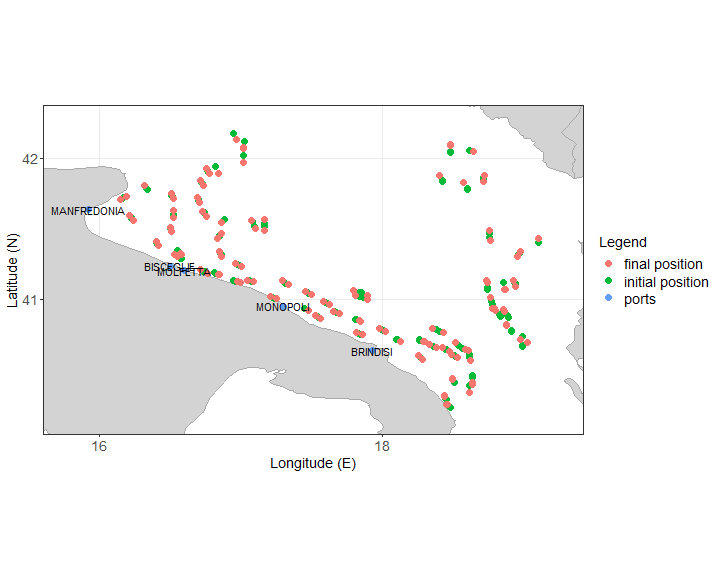

```r
RCG_check_loc(data_ex)
```

## Checks on CL

This function `RCG_check_CL` allows to check the data in the CL table for the selected species. The output is a list of 6 data frames:

1. Sum of Landings by year, quarter and month;

```r
RCG_check_CL(data_exampleCL,MS="COUNTRY1",GSA="GSA99",SP="Parapenaeus longirostris")[[1]]
```

```
#>    Year Quarter Month Sum_Landings
#> 1  2014       1     1     80553.10
#> 2  2014       1     2     80519.05
#> 3  2014       1     3     85107.68
#> 4  2014       2     4     90093.59
#> 5  2014       2     5    110096.34
#> 6  2014       2     6    117515.89
#> 7  2014       3     7     98584.85
#> 8  2014       3     8     49500.43
#> 9  2014       3     9     32084.59
#> 10 2014       4    10    153080.70
#> 11 2014       4    11    123574.70
#> 12 2014       4    12     99743.72
```

1. Sum of Landing value by year, quarter and month;

```r
RCG_check_CL(data_exampleCL,MS="COUNTRY1",GSA="GSA99",SP="Parapenaeus longirostris")[[2]]
```

```
#>    Year Quarter Month Sum_LandingsValue
#> 1  2014       1     1          410296.6
#> 2  2014       1     2          400928.4
#> 3  2014       1     3          476691.5
#> 4  2014       2     4          438991.9
#> 5  2014       2     5          521380.8
#> 6  2014       2     6          571712.2
#> 7  2014       3     7          518606.2
#> 8  2014       3     8          308576.7
#> 9  2014       3     9          161772.9
#> 10 2014       4    10          609361.4
#> 11 2014       4    11          576900.8
#> 12 2014       4    12          601217.8
```

1. Sum of landings by LandCtry, VslFlgCtry, Area, Rect, SubRect, Harbour;

```r
RCG_check_CL(data_exampleCL,MS="COUNTRY1",GSA="GSA99",SP="Parapenaeus longirostris")[[3]]
```

```
#>    Country  Area Harbour Sum_Landings
#> 1 COUNTRY1 GSA99    Port      1120455
```

1. Sum of landing value by LandCtry, VslFlgCtry, Area, Rect, SubRect, Harbour;

```r
RCG_check_CL(data_exampleCL,MS="COUNTRY1",GSA="GSA99",SP="Parapenaeus longirostris")[[4]]
```

```
#>    Country  Area Harbour Sum_LandingsValue
#> 1 COUNTRY1 GSA99    Port           5596437
```

1. Sum of landings by Year, Species, foCatEu5, foCatEu6;

```r
RCG_check_CL(data_exampleCL,MS="COUNTRY1",GSA="GSA99",SP="Parapenaeus longirostris")[[5]]
```

```
#>   Year                  Species fishing_activity_category_national
#> 1 2014 Parapenaeus longirostris                         OTB_ mixed
#> 2 2014 Parapenaeus longirostris                          OTB_shelf
#> 3 2014 Parapenaeus longirostris                          OTB_slope
#>   fishing_activity_category_eu_l6 Sum_Landings
#> 1                OTB_MDD_>=40_0_0   100918.089
#> 2                OTB_DEF_>=40_0_0  1018083.081
#> 3                OTB_DWS_>=40_0_0     1453.471
```

1. Sum of landing value by Year, Species, foCatEu5, foCatEu6.

```r
RCG_check_CL(data_exampleCL,MS="COUNTRY1",GSA="GSA99",SP="Parapenaeus longirostris")[[6]]
```

```
#>   Year                  Species fishing_activity_category_national
#> 1 2014 Parapenaeus longirostris                         OTB_ mixed
#> 2 2014 Parapenaeus longirostris                          OTB_shelf
#> 3 2014 Parapenaeus longirostris                          OTB_slope
#>   fishing_activity_category_eu_l6 Sum_LandingsValue
#> 1                OTB_MDD_>=40_0_0        537986.519
#> 2                OTB_DEF_>=40_0_0       5050728.907
#> 3                OTB_DWS_>=40_0_0          7721.884
```

1. Plot of the landings by year and foCatEu6

```r
RCG_check_CL(data_exampleCL,MS="COUNTRY1",GSA="GSA99",SP="Parapenaeus longirostris")[[7]]
```

```
#> i Do you need to adjust the group aesthetic?
```

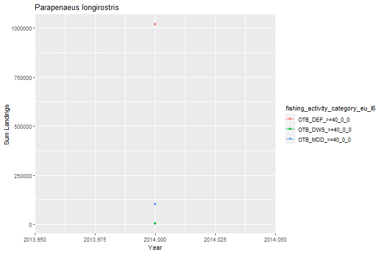

```r
`geom_line()`: Each group consists of only one observation.
```

# Checks on MEDBS tables

*catch table*

```r
head(Catch_tab_example)
```

```
#>                              id country year quarter vessel_length gear
#> 1       ITA 2008-1GNS-1DEMFSA 9     ITA 2008      -1            -1  GNS
#> 2   ITA 2010-1OTB50D100DWSPSA 9     ITA 2010      -1            -1  OTB
#> 3   ITA 2014-1OTB50D100DWSPSA 9     ITA 2014      -1            -1  OTB
#> 4  ITA 2008-1OTB50D100DEMSPSA 9     ITA 2008      -1            -1  OTB
#> 5 ITA 2008-1OTB50D100MDDWSPSA 9     ITA 2008      -1            -1  OTB
#> 6  ITA 2007-1OTB50D100DEMSPSA 9     ITA 2007      -1            -1  OTB
#>   mesh_size_range fishery  area specon species  landings discards
#> 1              -1    DEMF GSA 9     -1     DPS   0.50829       -1
#> 2          50D100    DWSP GSA 9     -1     DPS   9.69116       -1
#> 3          50D100    DWSP GSA 9     -1     DPS   2.11283       -1
#> 4          50D100   DEMSP GSA 9     -1     DPS 187.26219       -1
#> 5          50D100  MDDWSP GSA 9     -1     DPS  66.06531       -1
#> 6          50D100   DEMSP GSA 9     -1     DPS  89.84975       -1
#>   no_samples_landings no_length_measurements_landings
```

[output cut: 328 more lines]

*landings table*

```r
head(Landing_tab_example)
```

```
#>                             id country year quarter vessel_length gear
#> 1     ITA 2003 1GTR-1DEMSPSA 9     ITA 2003      -1            -1  GTR
#> 2      ITA 2003 1OTB50D100SA 9     ITA 2003      -1            -1  OTB
#> 3      ITA 2004-1GNS-1DEMFSA 9     ITA 2004      -1            -1  GNS
#> 4     ITA 2004-1GTR-1DEMSPSA 9     ITA 2004      -1            -1  GTR
#> 5 ITA 2004-1OTB50D100DEMSPSA 9     ITA 2004      -1            -1  OTB
#> 6     ITA 2005-1GTR-1DEMSPSA 9     ITA 2005      -1            -1  GTR
#>   mesh_size_range fishery  area specon species   landings unit lengthclass0
#> 1              -1   DEMSP GSA 9     -1     DPS   5.933227   mm            0
#> 2          50D100      -1 GSA 9     -1     DPS 316.615971   mm            0
#> 3              -1    DEMF GSA 9     -1     DPS   3.628830   mm            0
#> 4              -1   DEMSP GSA 9     -1     DPS   4.177760   mm            0
#> 5          50D100      -1 GSA 9     -1     DPS 367.431910   mm            0
#> 6              -1   DEMSP GSA 9     -1     DPS   0.517960   mm            0
#>   lengthclass1 lengthclass2 lengthclass3 lengthclass4 lengthclass5 lengthclass6
```

[output cut: 139 more lines]

*discards table*

```r
head(Discard_tab_example)
```

```
#>      id country year quarter vessel_length gear mesh_size_range fishery  area
#> 1 44554     ITA 2009      -1            -1  OTB          50D100   DEMSP GSA 9
#> 2 44571     ITA 2010      -1            -1  OTB          50D100   DEMSP GSA 9
#> 3 44583     ITA 2010      -1            -1  OTB          50D100  MDDWSP GSA 9
#> 4 44593     ITA 2011      -1            -1  OTB          50D100   DEMSP GSA 9
#> 5 44603     ITA 2011      -1            -1  OTB          50D100  MDDWSP GSA 9
#> 6 44612     ITA 2012      -1            -1  OTB          50D100   DEMSP GSA 9
#>   specon species  discards unit lengthclass0 lengthclass1 lengthclass2
#> 1     -1     DPS 38.355420   mm            0            0            0
#> 2     -1     DPS 24.396528   mm            0            0            0
#> 3     -1     DPS  2.703603   mm            0            0            0
#> 4     -1     DPS 60.519315   mm            0            0            0
#> 5     -1     DPS  2.743526   mm            0            0            0
#> 6     -1     DPS  6.571266   mm            0            0            0
#>   lengthclass3 lengthclass4 lengthclass5 lengthclass6 lengthclass7 lengthclass8
```

[output cut: 139 more lines]

## Checks on Catch table

The function `MEDBS_check_duplicates` checks the presence of duplicated rows in catch table

```r
catch_with_diplicate <- rbind(Catch_tab_example,Catch_tab_example[1,])
MEDBS_check_duplicates(data=catch_with_diplicate,type="c",MS="ITA",GSA="GSA 9",SP="DPS",verbose=TRUE)
```

```
#> There is/are 1 replicated row/rows in the data.
#>                         ID COUNTRY YEAR QUARTER VESSEL_LENGTH GEAR
#> 58 ITA 2008-1GNS-1DEMFSA 9     ITA 2008      -1            -1  GNS
#>    MESH_SIZE_RANGE FISHERY  AREA SPECON SPECIES LANDINGS DISCARDS
#> 58              -1    DEMF GSA 9     -1     DPS  0.50829        0
#>    NO_SAMPLES_LANDINGS NO_LENGTH_MEASUREMENTS_LANDINGS
#> 58                  30                               0
#>    NO_AGE_MEASUREMENTS_LANDINGS NO_SAMPLES_DISCARDS
#> 58                            0                   0
#>    NO_LENGTH_MEASUREMENTS_DISCARDS NO_AGE_MEASUREMENTS_DISCARDS
#> 58                              -1                           -1
#>    NO_SAMPLES_CATCH NO_LENGTH_MEASUREMENTS_CATCH NO_AGE_MEASUREMENTS_CATCH
#> 58               -1                           -1                        -1
#>    MIN_AGE MAX_AGE
#> 58      -1      -1
```

### Check catches coverage

The function `MEDBS_Catch_coverage` allows to check the coverage in Catch table by mean of summary tables summarizing both landing and discard volumes and producing relative plots for the selected species. In particular:

1. summary table of landings

```r
results <- suppressMessages(MEDBS_Catch_coverage(Catch_tab_example,"DPS","ITA","GSA 9"))
head(results[[1]])
```

```
#>   country year quarter vessel_length gear mesh_size_range fishery  area species
#> 1     ITA 2003      -1            -1  GTR              -1   DEMSP GSA 9     DPS
#> 2     ITA 2003      -1            -1  OTB              -1   DEMSP GSA 9     DPS
#> 3     ITA 2004      -1            -1  GNS              -1    DEMF GSA 9     DPS
#> 4     ITA 2004      -1            -1  GTR              -1   DEMSP GSA 9     DPS
#> 5     ITA 2004      -1            -1  OTB          50D100      -1 GSA 9     DPS
#> 6     ITA 2005      -1            -1  GTR              -1   DEMSP GSA 9     DPS
#>     landings
#> 1   5.933227
#> 2 316.615971
#> 3   3.628830
#> 4   4.177760
#> 5 367.431910
#> 6   0.517960
```

1. summary table of discards

```r
head(results[[2]])
```

```
#>   country year quarter vessel_length gear mesh_size_range fishery  area species
#> 1     ITA 2003      -1            -1  GTR              -1   DEMSP GSA 9     DPS
#> 2     ITA 2003      -1            -1  OTB              -1   DEMSP GSA 9     DPS
#> 3     ITA 2006      -1            -1  OTB          50D100   DEMSP GSA 9     DPS
#> 4     ITA 2006      -1            -1  OTB          50D100  MDDWSP GSA 9     DPS
#> 5     ITA 2009      -1            -1  OTB          50D100   DEMSP GSA 9     DPS
#> 6     ITA 2009      -1            -1  OTB          50D100  MDDWSP GSA 9     DPS
#>   discards
#> 1  0.00000
#> 2  0.00000
#> 3  0.00000
#> 4  0.00000
#> 5 38.35542
#> 6  0.00000
```

1. Plot of landing volumes in catch table

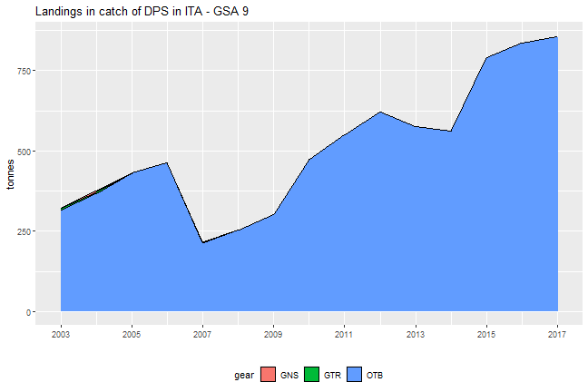

```r
results[[3]]
```

1. Plot of discard volumes in catch table

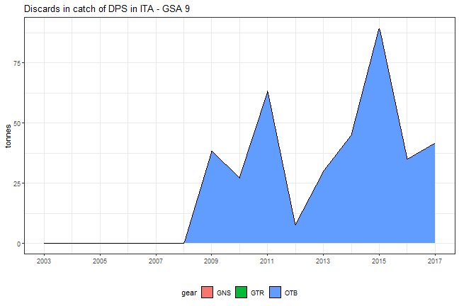

```r
results[[4]]
```

### check Sum of products (SOP)

The function checks if the percentage difference between SOP and both volumes of landing and discard are greater then a threshold value. The default value is fixed to 5%.

threshold = 5

```r
MEDBS_SOP(data=Catch_tab_example,SP="DPS",MS="ITA",GSA="GSA 9",threshold = 5)
```

```
#>    YEAR QUARTER VESSEL_LENGTH GEAR MESH_SIZE_RANGE FISHERY check_LANDING
#> 24 2009      -1            -1  OTB          50D100   DEMSP
#> 25 2014      -1            -1  OTB          50D100   DEMSP
#> 54 2017       4            -1  OTB          50D100   DEMSP
#>    check_DISCARD
#> 24          7.68
#> 25          5.53
#> 54          7.73
```

threshold = 2

```r
MEDBS_SOP(data=Catch_tab_example,SP="DPS",MS="ITA",GSA="GSA 9",threshold = 2)
```

```
#>    YEAR QUARTER VESSEL_LENGTH GEAR MESH_SIZE_RANGE FISHERY check_LANDING
#> 11 2004      -1            -1  OTB          50D100      -1          2.98
#> 21 2011      -1            -1  OTB          50D100   DEMSP
#> 24 2009      -1            -1  OTB          50D100   DEMSP         -3.62
#> 25 2014      -1            -1  OTB          50D100   DEMSP
#> 30 2017       1            -1  OTB          50D100   DEMSP         -3.37
#> 32 2017       4            -1  OTB          50D100  MDDWSP          2.05
#> 40 2016       3            -1  OTB          50D100  MDDWSP          2.84
#> 43 2016       3            -1  OTB          50D100   DEMSP
#> 44 2012      -1            -1  OTB          50D100  MDDWSP
#> 54 2017       4            -1  OTB          50D100   DEMSP          2.89
#>    check_DISCARD
#> 11
#> 21          4.96
#> 24          7.68
#> 25          5.53
#> 30          2.07
#> 32
#> 40
#> 43          3.29
#> 44          3.88
#> 54          7.73
```

## Checks on discard and landing tables

### check duplicated records

The function `MEDBS_check_duplicates` checks the presence of duplicated rows in landings

```r
Landing_tab_example <- rbind(Landing_tab_example,Landing_tab_example[1,])
MEDBS_check_duplicates(data=Landing_tab_example,type="l",MS="ITA",GSA="GSA 9",SP="DPS",verbose=TRUE)
```

```
#> There is/are 1 replicated row/rows in the data.
#>                          ID COUNTRY YEAR QUARTER VESSEL_LENGTH GEAR
#> 58 ITA 2003 1GTR-1DEMSPSA 9     ITA 2003      -1            -1  GTR
#>    MESH_SIZE_RANGE FISHERY  AREA SPECON SPECIES LANDINGS
#> 58              -1   DEMSP GSA 9     -1     DPS 5.933227
```

```r
Discard_tab_example <- rbind(Discard_tab_example,Discard_tab_example[1,])
MEDBS_check_duplicates(data=Discard_tab_example,type="d",SP="DPS",MS="ITA",GSA="GSA 9",verbose=TRUE)
```

```
#> There is/are 1 replicated row/rows in the data.
#>       ID COUNTRY YEAR QUARTER VESSEL_LENGTH GEAR MESH_SIZE_RANGE FISHERY  AREA
#> 22 44554     ITA 2009      -1            -1  OTB          50D100   DEMSP GSA 9
#>    SPECON SPECIES DISCARDS
#> 22     -1     DPS 38.35542
```

## Kolmogorov-Smirnov test

The function `MEDBS_ks` allows to perform the Kolmogorov-Smirnov test on both landings and discards for a selected species. The function performs Kolmogorov-Smirnov tests on couples of years to assess if they belong to the same population, returning a summary data frame. The function returns also the cumulative length distribution plots by fishery and year.

```r
ks <- MEDBS_ks(data=Landing_tab_example, type="l", SP="DPS",MS="ITA",GSA="GSA 9",Rt=1)
```

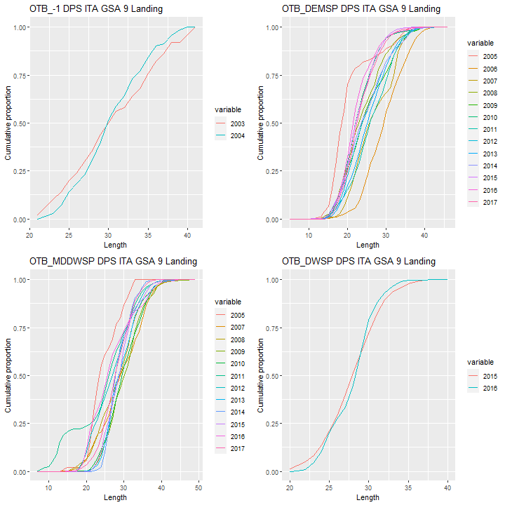

```r
results <- ks[[1]]
head(results)
```

```
#>   year gear fishery total_number min_size mean_size max_size  sd_size
#> 1 2003  GTR   DEMSP         0.00       NA        NA       NA       NA
#> 2 2003  OTB      -1     18516.42       21  30.94000       41 5.460587
#> 3 2004  GNS    DEMF         0.00       NA        NA       NA       NA
#> 4 2004  GTR   DEMSP         0.00       NA        NA       NA       NA
#> 5 2004  OTB      -1     22257.63       22  30.77143       40 4.316747
#> 6 2005  GTR   DEMSP         0.00       NA        NA       NA       NA
```

```r
# plot(ks[[3]])
```

### Check consistency of length data

The function `MEDBS_length_ind` allows to check the consistency of length data for a selected species on both landings and discards returning a summary table of the main length size indicators time series by fishery.

```r
results <- MEDBS_length_ind(Discard_tab_example,type="d",SP="DPS",MS=c("ITA"),GSA=c("GSA 9"), splines=c(0.2,0.4,0.6,0.8),Xtresholds = c(0.25,0.5,0.75))
head(results[[1]])
```

```
#>   year gear fishery total_number min_size mean_size max_size  sd_size spline
#> 1 2009  OTB   DEMSP     22633.62        8  16.18669       35 3.691644    0.2
#> 2 2009  OTB   DEMSP     22633.62        8  16.18669       35 3.691644    0.2
#> 3 2009  OTB   DEMSP     22633.62        8  16.18669       35 3.691644    0.2
#> 4 2009  OTB   DEMSP     22633.62        8  16.18669       35 3.691644    0.4
#> 5 2009  OTB   DEMSP     22633.62        8  16.18669       35 3.691644    0.4
#> 6 2009  OTB   DEMSP     22633.62        8  16.18669       35 3.691644    0.4
#>   percentile percentile_value
#> 1       0.25         12.97333
#> 2       0.50         15.37941
#> 3       0.75         18.07179
#> 4       0.25         10.17795
#> 5       0.50         14.99112
#> 6       0.75         19.41598
```

A plot of the time series of mean length in discards and landings is returned.

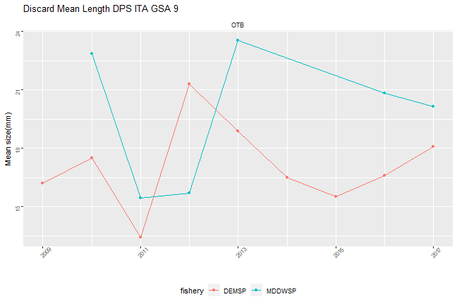

```r
results[[2]]
```

A plot of the time series of median length in discards and landings is returned.

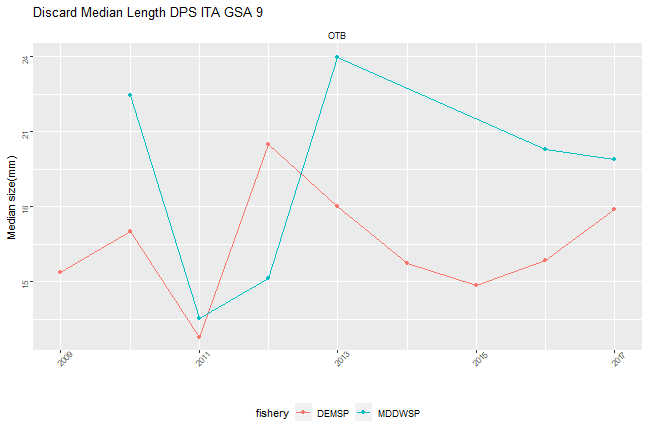

```r
results[[3]]
```

### Check of null individuals in landings and discards

The function `MEDBS_lengthclass_0` checks landings and discards for the presence of length class filled in having weigth > 0, returning a data frame with the rows with 0 values length class having weigth > 0.

```r
results <- MEDBS_lengthclass_0(data=Landing_tab_example,type="l",SP="DPS",MS="ITA",GSA="GSA 9",verbose=TRUE)
```

```
#> 17 cases in which length class number are zero and landings > 0
```

```r
head(results)
```

```
#>                               id country year quarter vessel_length gear
#> 1       ITA 2003 1GTR-1DEMSPSA 9     ITA 2003      -1            -1  GTR
#> 3        ITA 2004-1GNS-1DEMFSA 9     ITA 2004      -1            -1  GNS
#> 4       ITA 2004-1GTR-1DEMSPSA 9     ITA 2004      -1            -1  GTR
#> 6       ITA 2005-1GTR-1DEMSPSA 9     ITA 2005      -1            -1  GTR
#> 10 ITA 2006-1OTB50D100MDDWSPSA 9     ITA 2006      -1            -1  OTB
#> 11       ITA 2007-1GNS-1DEMFSA 9     ITA 2007      -1            -1  GNS
#>    mesh_size_range fishery  area specon species   landings ck_0_length
#> 1               -1   DEMSP GSA 9     -1     DPS   5.933227           0
#> 3               -1    DEMF GSA 9     -1     DPS   3.628830           0
#> 4               -1   DEMSP GSA 9     -1     DPS   4.177760           0
#> 6               -1   DEMSP GSA 9     -1     DPS   0.517960           0
#> 10          50D100  MDDWSP GSA 9     -1     DPS 407.103060           0
#> 11              -1    DEMF GSA 9     -1     DPS   2.263080           0
```

### weight 0 in landings and discards

The function `MEDBS_weight_0` checks landings or discards in weight equal to 0 having length classes filled in, returning the number of rows with 0 values in weights having length classes filled in.

```r
MEDBS_weight_0(data=Discard_tab_example,type="d",SP="DPS",MS="ITA",GSA="GSA 9", verbose=TRUE)
```

```
#> There aren't 0 discards
#>  [1] id              country         year            quarter
#>  [5] vessel_length   gear            mesh_size_range fishery
#>  [9] area            specon          species         discards
#> [13] unit
#> <0 righe> (o 0-length row.names)
```

### weight -1 in landings and discards

The function `MEDBS_weight_minus1` checks landings in weight equal to -1 having length class filled in, returning the number of rows with -1 values in landing weights having length class filled in.

```r
MEDBS_weight_minus1(data=Discard_tab_example,type="d",SP="DPS",MS="ITA",GSA="GSA 9",verbose=TRUE)
```

```
#> There aren't -1 discards
#>  [1] id              country         year            quarter
#>  [5] vessel_length   gear            mesh_size_range fishery
#>  [9] area            specon          species         discards
#> [13] unit
#> <0 righe> (o 0-length row.names)
```

### Years with missing length distributions

The function `MEDBS_yr_missing_length` checks the presence of years with missing length distributions in both landings and discards for a selected species. A data frame of the missing length distributions is returned.

```r
results <- MEDBS_yr_missing_length(data=Landing_tab_example,type="l",SP="DPS",MS="ITA",GSA="GSA 9")
head(results)
```

```
#>   year gear fishery total_number_landed
#> 1 2003  GTR   DEMSP                   0
#> 2 2004  GNS    DEMF                   0
#> 3 2004  GTR   DEMSP                   0
#> 4 2005  GTR   DEMSP                   0
#> 5 2006  OTB  MDDWSP                   0
#> 6 2007  GNS    DEMF                   0
```

## Checks on landings

### Comparison between landings in weight by quarter accounting for vessel length

The function `MEDBS_comp_land_Q_VL` allows to perform the comparison of landings of a selected species aggregated by quarters accounting for the presence of vessel length. A dataframe for the comparison of landings aggregated by quarters accounting for the presence of vessel length information is returned.

```r
results <- suppressMessages(MEDBS_comp_land_Q_VL(data = Landing_tab_example,
           SP = "DPS", MS = "ITA", GSA = "GSA 9"))
head(results)
```

```
#>   YEAR GEAR QUARTER    tot_VL tot_NoVL ratio
#> 1 2003  GTR      -1  11.86645       NA    NA
#> 2 2003  OTB      -1 316.61597       NA    NA
#> 3 2004  GNS      -1   3.62883       NA    NA
#> 4 2004  GTR      -1   4.17776       NA    NA
#> 5 2004  OTB      -1 367.43191       NA    NA
#> 6 2005  GTR      -1   0.51796       NA    NA
```

### Comparison between landings in weight by quarter and fishery accounting for vessel length

The function `MEDBS_comp_land_Q_VL_fishery` allows to perform the comparison of landings of a selected species aggregated by quarters and fishery accounting for the presence of vessel length. The function returns a data frame for the comparison of landings aggregated by quarters and fishery accounting for the presence of vessel length information.

```r
results <- suppressMessages(MEDBS_comp_land_Q_VL_fishery(data = Landing_tab_example,
        MS = "ITA", GSA = "GSA 9", SP = "DPS"))
head(results)
```

```
#>   YEAR GEAR FISHERY QUARTER    tot_VL tot_NoVL ratio
#> 1 2003  GTR   DEMSP      -1  11.86645       NA    NA
#> 2 2003  OTB      -1      -1 316.61597       NA    NA
#> 3 2004  GNS    DEMF      -1   3.62883       NA    NA
#> 4 2004  GTR   DEMSP      -1   4.17776       NA    NA
#> 5 2004  OTB      -1      -1 367.43191       NA    NA
#> 6 2005  GTR   DEMSP      -1   0.51796       NA    NA
```

### Comparison between landings in weight by quarter and -1

The function `MEDBS_comp_land_YQ` allows to perform the comparison of landings of a selected species aggregated by quarters and by year. The function returns a data frame for the comparison of landings aggregated by quarters and by year.

```r
MEDBS_comp_land_YQ(data=Landing_tab_example,SP="DPS",MS="ITA",GSA="GSA 9")
```

```
#>    YEAR GEAR     tot_q    tot_yr  ratio
#> 1  2003  GTR        NA  11.86645     NA
#> 2  2003  OTB        NA 316.61597     NA
#> 3  2004  GNS        NA   3.62883     NA
#> 4  2004  GTR        NA   4.17776     NA
#> 5  2004  OTB        NA 367.43191     NA
#> 6  2005  GTR        NA   0.51796     NA
#> 7  2005  OTB        NA 430.42544     NA
#> 8  2006  OTB        NA 462.40605     NA
#> 9  2007  GNS        NA   2.26308     NA
#> 10 2007  OTB        NA 215.16790     NA
#> 11 2008  GNS        NA   0.50829     NA
#> 12 2008  OTB        NA 253.49215     NA
#> 13 2009  OTB        NA 303.14069     NA
#> 14 2010  OTB        NA 473.29438     NA
#> 15 2011  OTB        NA 551.03147     NA
#> 16 2012  GTR        NA   0.16116     NA
#> 17 2012  OTB        NA 621.08818     NA
#> 18 2013  OTB        NA 575.66107     NA
#> 19 2014  GNS        NA   0.02736     NA
#> 20 2014  OTB        NA 561.43756     NA
#> 21 2015  OTB        NA 791.44936     NA
#> 22 2016  OTB 825.13200  10.47800 78.749
#> 23 2017  GNS   0.02688        NA     NA
#> 24 2017  OTB 856.80650        NA     NA
```

### Comparison between landings in weight by quarter, quarter -1 and by fishery

The function `MEDBS_comp_land_YQ_fishery` allows to perform the comparison of landings of a selected species aggregated by quarters and by year and fishery. The function returns a data frame for the comparison of landings aggregated by quarters and by year and fishery.

```r
results <- suppressMessages(MEDBS_comp_land_YQ_fishery(data = Landing_tab_example, SP = "DPS", MS = "ITA", GSA = "GSA 9"))
head(results)
```

```
#>   YEAR GEAR FISHERY tot_q    tot_yr ratio
#> 1 2003  GTR   DEMSP    NA  11.86645    NA
#> 2 2003  OTB      -1    NA 316.61597    NA
#> 3 2004  GNS    DEMF    NA   3.62883    NA
#> 4 2004  GTR   DEMSP    NA   4.17776    NA
#> 5 2004  OTB      -1    NA 367.43191    NA
#> 6 2005  GTR   DEMSP    NA   0.51796    NA
```

### Check mean weight by year,gear and fishery aggregation

The function `MEDBS_land_mean_weight` allows to check consistency of mean landing of a selected species plotting the landings' weight by year, gear and fishery. A summary data frame is returned.

```r
results <- MEDBS_land_mean_weight(data=Landing_tab_example,SP="DPS",MS="ITA",GSA="GSA 9")[[1]]
head(results)
```

```
#>   year quarter vessel_length gear mesh_size_range fishery      totW     totN
#> 1 2003      -1            -1  GTR              -1   DEMSP  11866454        0
#> 2 2003      -1            -1  OTB          50D100      -1 316615971 18516419
#> 3 2004      -1            -1  GNS              -1    DEMF   3628830        0
#> 4 2004      -1            -1  GTR              -1   DEMSP   4177760        0
#> 5 2004      -1            -1  OTB          50D100      -1 367431910 22257632
#> 6 2005      -1            -1  GTR              -1   DEMSP    517960        0
#>      MW(g)
#> 1       NA
#> 2 17.09920
#> 3       NA
#> 4       NA
#> 5 16.50813
#> 6       NA
```

The function returns a plot of the mean landing weight by year, gear and fishery aggregation as well.

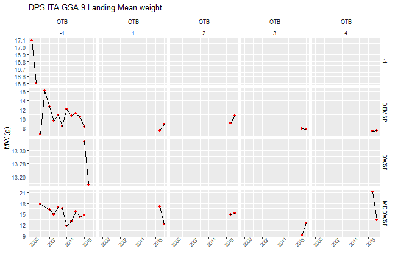

```r
MEDBS_land_mean_weight(data=Landing_tab_example,SP="DPS",MS="ITA",GSA="GSA 9")[[2]]
```

### Plot of total landing by gear and fishery

The function `MEDBS_plot_land_vol` allows to visual check the time series of landing volumes by fishery of a selected species. The function returns a plot of the total landing time series by fishery and gear.

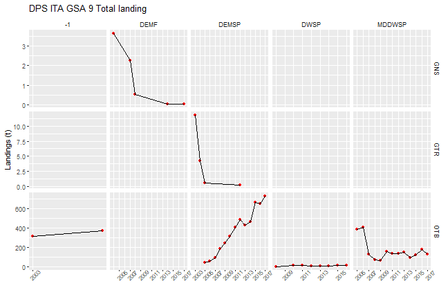

```r
MEDBS_plot_land_vol(data=Landing_tab_example,SP="DPS",MS="ITA",GSA="GSA 9")
```

### Plot of total landing

The function `MEDBS_plot_landing_ts` estimates the total landings time series by both year and quarters for a selected combination of member state, GSA and species. The function returns a plot of the total landing time series by year or by quarters. The plot by year also reports the landing by gear.

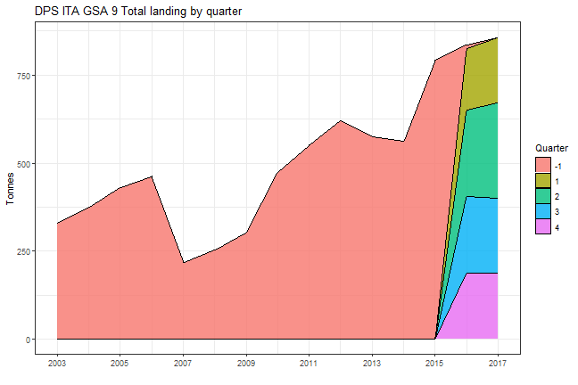

```r
suppressMessages(MEDBS_plot_landing_ts(data=Landing_tab_example,SP="DPS",MS="ITA",GSA="GSA 9",by="quarter"))
```

### check the coverage in Landing table

The function `MEDBS_Landing_coverage` allows to check the coverage in landing table providing a summary table

```r
results <- suppressMessages(MEDBS_Landing_coverage(Landing_tab_example,"DPS","ITA","GSA 9"))
head(results[[1]])
```

```
#>   country year quarter vessel_length gear mesh_size_range fishery  area species
#> 1     ITA 2003      -1            -1  GTR              -1   DEMSP GSA 9     DPS
#> 2     ITA 2003      -1            -1  OTB          50D100      -1 GSA 9     DPS
#> 3     ITA 2004      -1            -1  GNS              -1    DEMF GSA 9     DPS
#> 4     ITA 2004      -1            -1  GTR              -1   DEMSP GSA 9     DPS
#> 5     ITA 2004      -1            -1  OTB          50D100      -1 GSA 9     DPS
#> 6     ITA 2005      -1            -1  GTR              -1   DEMSP GSA 9     DPS
#>    landings
#> 1  11.86645
#> 2 316.61597
#> 3   3.62883
#> 4   4.17776
#> 5 367.43191
#> 6   0.51796
```

a plot of the landing coverage is also provided.

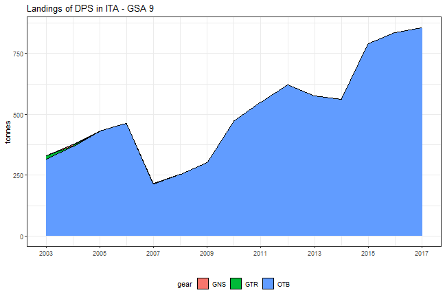

```r
results[[2]]
```

## Checks on discards

### check the coverage in discard table

The function `MEDBS_discard_coverage` allows to check the coverage of the time series in discard table for a selected species. The function returns a summary table.

```r
results <- suppressMessages(MEDBS_discard_coverage(Discard_tab_example,"DPS","ITA","GSA 9"))
head(results[[1]])
```

```
#>   country year quarter vessel_length gear mesh_size_range fishery  area species
#> 1     ITA 2009      -1            -1  OTB          50D100   DEMSP GSA 9     DPS
#> 2     ITA 2010      -1            -1  OTB          50D100   DEMSP GSA 9     DPS
#> 3     ITA 2010      -1            -1  OTB          50D100  MDDWSP GSA 9     DPS
#> 4     ITA 2011      -1            -1  OTB          50D100   DEMSP GSA 9     DPS
#> 5     ITA 2011      -1            -1  OTB          50D100  MDDWSP GSA 9     DPS
#> 6     ITA 2012      -1            -1  OTB          50D100   DEMSP GSA 9     DPS
#>    discards
#> 1 76.710840
#> 2 24.396528
#> 3  2.703603
#> 4 60.519315
#> 5  2.743526
#> 6  6.571266
```

A plots of discard time series by year and gear is also provided.

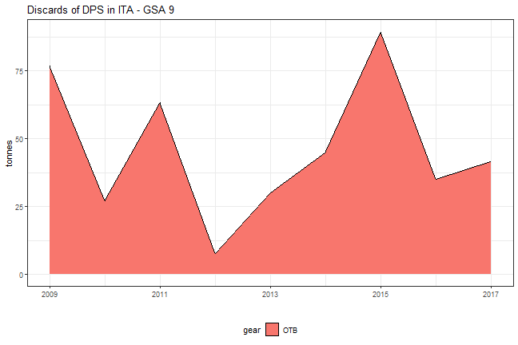

```r
results[[2]]
```

### Comparison between discards in weight by quarter and -1

The function `MEDBS_comp_disc_YQ` allows to compare the discards weights aggregated by quarter and by year for a selected species at the gear level. The function returns a data frame for the comparison of discards aggregated by quarters and by year

```r
MEDBS_comp_disc_YQ(data=Discard_tab_example,MS="ITA",GSA="GSA 9",SP="DPS")
```

```
#>   YEAR GEAR    TOT_Q    TOT_YR RATIO
#> 1 2009  OTB       NA 76.710840    NA
#> 2 2010  OTB       NA 27.100131    NA
#> 3 2011  OTB       NA 63.262841    NA
#> 4 2012  OTB       NA  7.568045    NA
#> 5 2013  OTB       NA 30.040906    NA
#> 6 2014  OTB       NA 44.978926    NA
#> 7 2015  OTB       NA 89.320018    NA
#> 8 2016  OTB 34.93873        NA    NA
#> 9 2017  OTB 41.46659        NA    NA
```

### Comparison between discards in weight by quarter, quarter -1 and by fishery

The function `MEDBS_comp_disc_YQ_fishery` allow to estimates the discards in weight for a selected species by quarter and fishery. The function returns a data frame for the comparison of discards aggregated by quarters and by year and fishery

```r
results <- MEDBS_comp_disc_YQ_fishery(data=Discard_tab_example,MS="ITA",GSA="GSA 9",SP="DPS")
head(results)
```

```
#>   YEAR GEAR FISHERY TOT_Q    TOT_YR RATIO
#> 1 2009  OTB   DEMSP    NA 76.710840    NA
#> 2 2010  OTB   DEMSP    NA 24.396528    NA
#> 3 2010  OTB  MDDWSP    NA  2.703603    NA
#> 4 2011  OTB   DEMSP    NA 60.519315    NA
#> 5 2011  OTB  MDDWSP    NA  2.743526    NA
#> 6 2012  OTB   DEMSP    NA  6.571266    NA
```

### Check mean weight by year,gear and fishery aggregation in discard

The function `MEDBS_disc_mean_weight` allows to check consistency of mean discard weight of a selected species providing a table of the mean individual weight by year, gear and fishery.

```r
results <- MEDBS_disc_mean_weight(data=Discard_tab_example,SP="DPS",MS="ITA",GSA="GSA 9")
head(results[[1]])
```

```
#>   YEAR QUARTER VESSEL_LENGTH GEAR MESH_SIZE_RANGE FISHERY     totW       totN
#> 1 2009      -1            -1  OTB          50D100   DEMSP 76710840 22633620.8
#> 2 2010      -1            -1  OTB          50D100   DEMSP 24396528  6011330.6
#> 3 2010      -1            -1  OTB          50D100  MDDWSP  2703603   345221.9
#> 4 2011      -1            -1  OTB          50D100   DEMSP 60519315 29133415.7
#> 5 2011      -1            -1  OTB          50D100  MDDWSP  2743526   744126.7
#> 6 2012      -1            -1  OTB          50D100   DEMSP  6571266   998156.0
#>      MW(g)
#> 1 3.389243
#> 2 4.058424
#> 3 7.831493
#> 4 2.077316
#> 5 3.686907
#> 6 6.583406
```

The function also returns a plot of the mean discards weight by year, gear and fishery aggregation.

```r
results[[2]]
```

```r
`geom_line()`: Each group consists of only one observation.
```

```
#> i Do you need to adjust the group aesthetic?
```

```
#> i Do you need to adjust the group aesthetic?
```

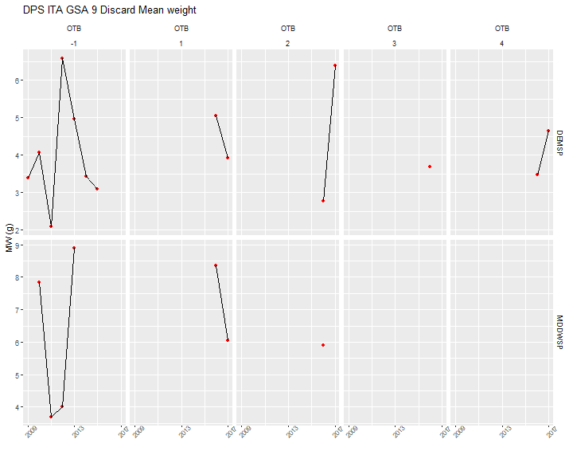

```r
`geom_line()`: Each group consists of only one observation.
```

### Plot of total discards by gear and fishery

The function `MEDBS_plot_disc_vol` allows to visual check the time series of discard volumes by fishery of a selected species. The function returns a plot of the total discards time series by fishery and gear.

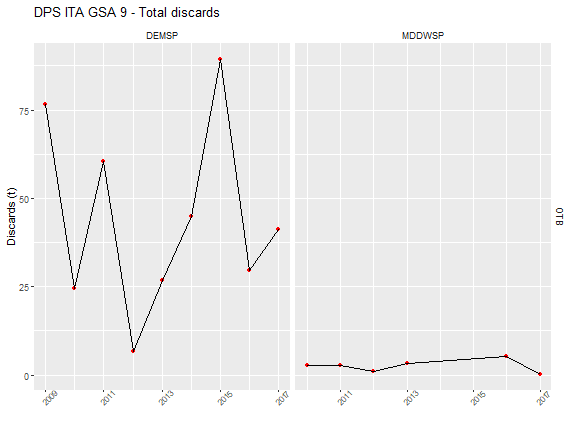

```r
MEDBS_plot_disc_vol(data=Discard_tab_example,SP="DPS",MS="ITA",GSA="GSA 9")
```

### Plot of total discards time series

The function `MEDBS_plot_discard_ts` estimates the total discard time series by both year and quarters for a selected combination of member state, GSA and species. The function returns a plot of the total discard time series by year or by quarters. The parameter `by="year"` also reports the landing by gear.

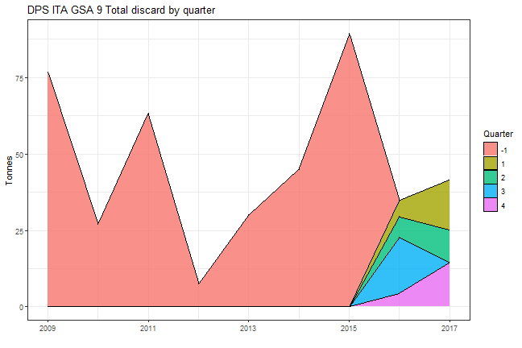

```r
MEDBS_plot_discard_ts(data=Discard_tab_example,SP="DPS",MS="ITA",GSA="GSA 9",by="quarter")
```

## Other checks

### GP_tab (growth params) table check

The function `GP_check` allows to check the growth parameters by sex and year for a selected species. The function returns a list of objects containing a summary table and different plots of the growth curves by sex

```r
results <- MEDBS_GP_check(GP_tab_example,"MUT","ITA","GSA 18")
results[[1]]
```

```
#>    COUNTRY   AREA START_YEAR END_YEAR SPECIES SEX COUNT
#> 1      ITA GSA 18       2014     2014     MUT   C     1
#> 2      ITA GSA 18       2014     2014     MUT   F     1
#> 3      ITA GSA 18       2014     2014     MUT   M     1
#> 4      ITA GSA 18       2015     2015     MUT   C     1
#> 5      ITA GSA 18       2015     2015     MUT   F     1
#> 6      ITA GSA 18       2015     2015     MUT   M     1
#> 7      ITA GSA 18       2016     2016     MUT   C     1
#> 8      ITA GSA 18       2016     2016     MUT   F     1
#> 9      ITA GSA 18       2016     2016     MUT   M     1
#> 10     ITA GSA 18       2017     2017     MUT   C     1
#> 11     ITA GSA 18       2017     2017     MUT   F     1
#> 12     ITA GSA 18       2017     2017     MUT   M     1
```

```r
print(names(results)[1])
```

```
#> [1] "summary table"
```

```r
print(names(results)[2])
```

```
#> [1] "VBGF _ MUT _ ITA _ GSA 18"
```

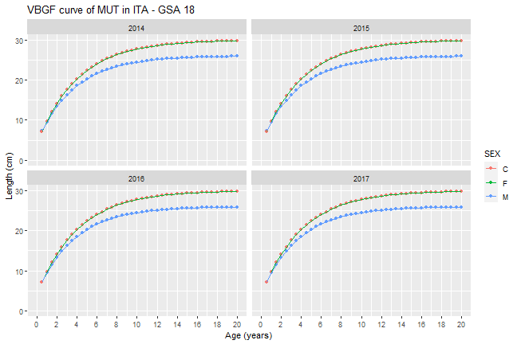

```r
results[[2]]
```

```r
print(names(results)[3])
```

```
#> [1] "VBGF_year _ MUT _ ITA _ GSA 18 _ F"
```

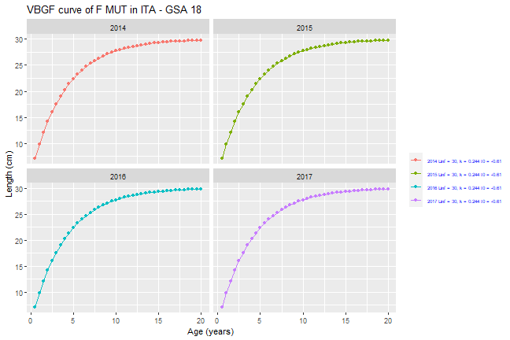

```r
results[[3]]
```

```r
print(names(results)[4])
```

```
#> [1] "VBGF_year _ MUT _ ITA _ GSA 18 _ M"
```

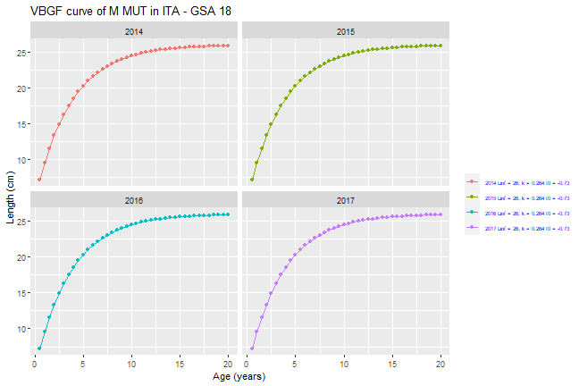

```r
results[[4]]
```

```r
print(names(results)[5])
```

```
#> [1] "VBGF_year _ MUT _ ITA _ GSA 18 _ C"
```

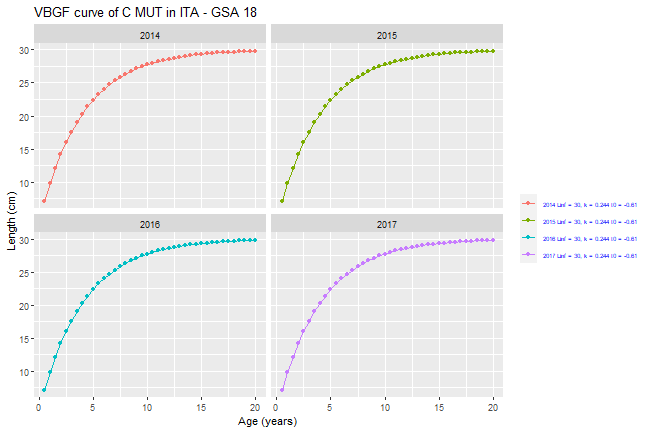

```r
results[[5]]
```

```r
print(names(results)[6])
```

```
#> [1] "VBGF_cum _ MUT _ ITA _ GSA 18 _ F"
```

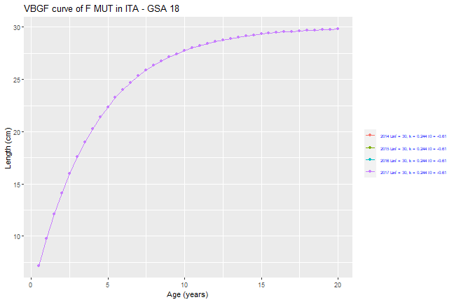

```r
results[[6]]
```

```r
print(names(results)[7])
```

```
#> [1] "VBGF_cum _ MUT _ ITA _ GSA 18 _ M"
```

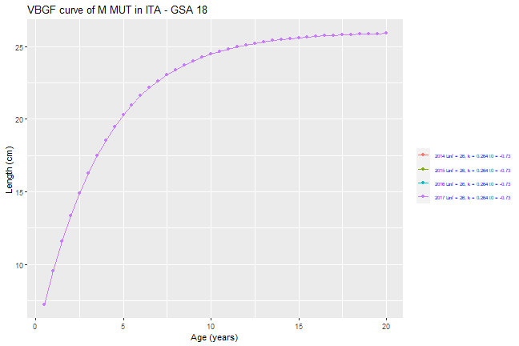

```r
results[[7]]
```

```r
print(names(results)[8])
```

```
#> [1] "VBGF_cum _ MUT _ ITA _ GSA 18 _ C"
```

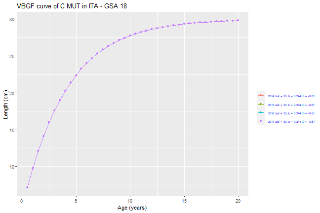

```r
results[[8]]
```

### LW params in GP_tab in table check

The function `MEDBS_LW_check` allows to check the length-weight parameters included in the GP table for a selected species. The function returns a summary table.

```r
results <- MEDBS_LW_check(GP_tab_example,"MUT","ITA","GSA 18")
results[[1]]
```

```
#>    COUNTRY   AREA START_YEAR END_YEAR SPECIES SEX CUNT
#> 1      ITA GSA 18       2014     2014     MUT   C    1
#> 2      ITA GSA 18       2014     2014     MUT   F    1
#> 3      ITA GSA 18       2014     2014     MUT   M    1
#> 4      ITA GSA 18       2015     2015     MUT   C    1
#> 5      ITA GSA 18       2015     2015     MUT   F    1
#> 6      ITA GSA 18       2015     2015     MUT   M    1
#> 7      ITA GSA 18       2016     2016     MUT   C    1
#> 8      ITA GSA 18       2016     2016     MUT   F    1
#> 9      ITA GSA 18       2016     2016     MUT   M    1
#> 10     ITA GSA 18       2017     2017     MUT   C    1
#> 11     ITA GSA 18       2017     2017     MUT   F    1
#> 12     ITA GSA 18       2017     2017     MUT   M    1
```

plots of the length-weigth relationships for the selected species by year and sex are also returned.

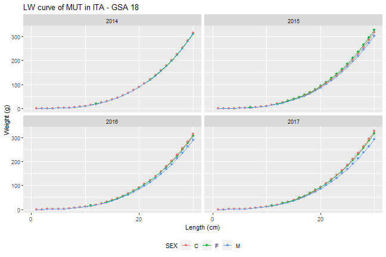

```r
results[[2]]
```

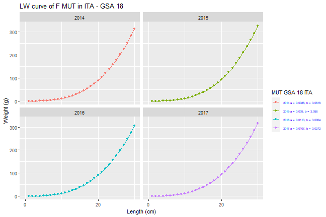

```r
results[[3]]
```

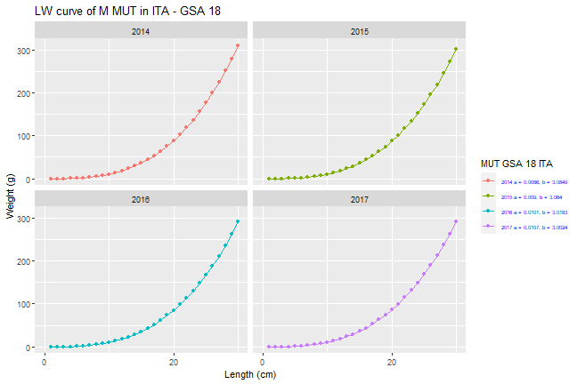

```r
results[[4]]
```

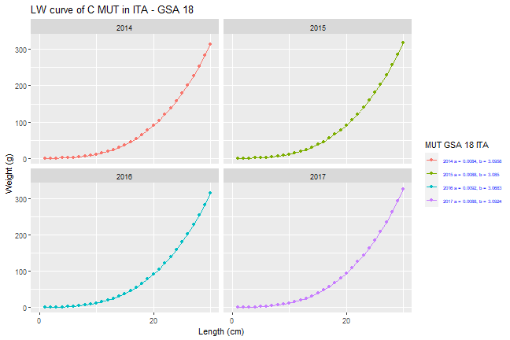

```r
results[[5]]
```

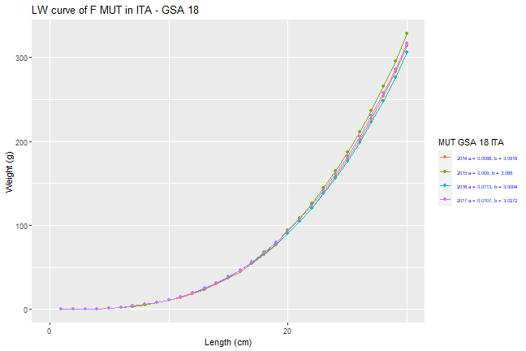

```r
results[[6]]
```

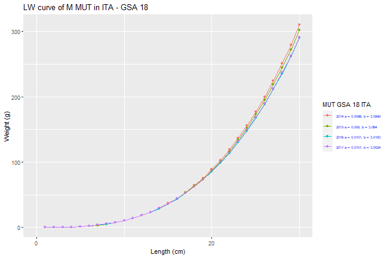

```r
results[[7]]
```

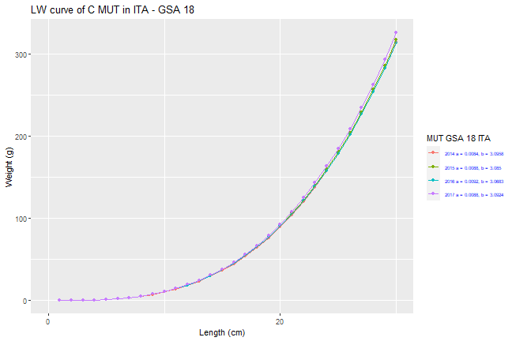

```r
results[[8]]
```

### MA_tab (maturity at age) table check

The function `MEDBS_MA_check` allows to check the maturity at age (MA) table providing a summary table of the data coverage.

```r
results <- MEDBS_MA_check(MA_tab_example,"DPS","ITA","GSA 99")
results[[1]]
```

```
#>    COUNTRY   AREA START_YEAR END_YEAR SPECIES SEX COUNT
#> 1      ITA GSA 99       2006     2006     DPS   F     6
#> 2      ITA GSA 99       2007     2007     DPS   F     6
#> 3      ITA GSA 99       2008     2008     DPS   F     6
#> 4      ITA GSA 99       2009     2009     DPS   F     6
#> 5      ITA GSA 99       2010     2010     DPS   F     6
#> 6      ITA GSA 99       2011     2011     DPS   F     6
#> 7      ITA GSA 99       2012     2012     DPS   F     6
#> 8      ITA GSA 99       2013     2013     DPS   F     6
#> 9      ITA GSA 99       2014     2014     DPS   F     6
#> 10     ITA GSA 99       2015     2015     DPS   F     5
#> 11     ITA GSA 99       2016     2016     DPS   F     6
#> 12     ITA GSA 99       2017     2016     DPS   F     6
```

The function also provides plots for the selected species of the proportion of matures for age class by sex and year.

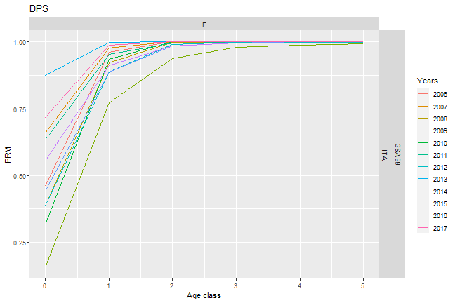

```r
results[[2]]
```

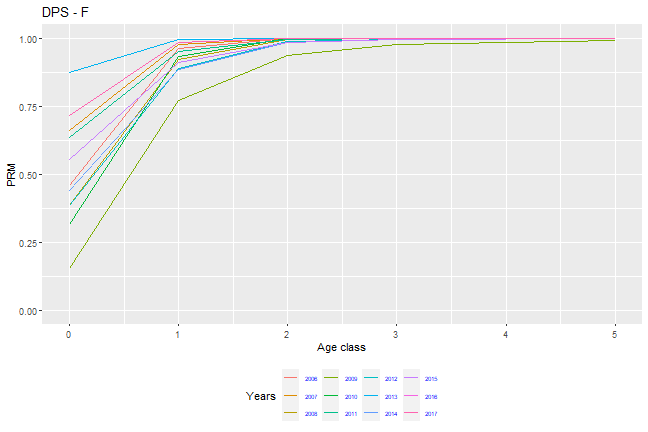

```r
results[[3]]
```

### ML_tab (maturity at length) table check

```r
results <- MEDBS_ML_check(ML_tab_example, "DPS", "ITA", "GSA 99")
```

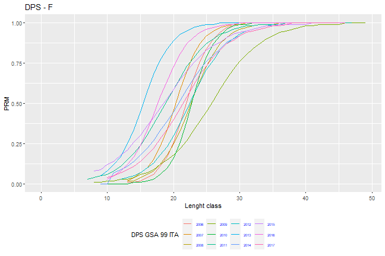

```r
results[[1]]
```

```
#>    COUNTRY   AREA START_YEAR END_YEAR SPECIES SEX COUNT
#> 1      ITA GSA 99       2006     2006     DPS   F    31
#> 2      ITA GSA 99       2007     2007     DPS   F    32
#> 3      ITA GSA 99       2008     2008     DPS   F    33
#> 4      ITA GSA 99       2009     2009     DPS   F    42
#> 5      ITA GSA 99       2010     2010     DPS   F    39
#> 6      ITA GSA 99       2011     2011     DPS   F    41
#> 7      ITA GSA 99       2012     2012     DPS   F    35
#> 8      ITA GSA 99       2013     2013     DPS   F    38
#> 9      ITA GSA 99       2014     2014     DPS   F    38
#> 10     ITA GSA 99       2015     2015     DPS   F    35
#> 11     ITA GSA 99       2016     2016     DPS   F    37
#> 12     ITA GSA 99       2017     2017     DPS   F    36
```

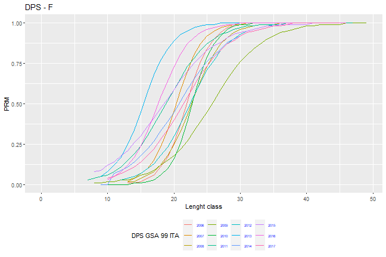

```r
results[[2]]
```

### SA_tab (sex ratio at age) table check

The function `MEDBS_SA_check` allows to check the sex ratio at age (SA) table providing a summary table of the data coverage for the selected species of the proportion of sex ratio for age class by year.

```r
results <- MEDBS_SA_check(SA_tab_example, "DPS", "ITA", "GSA 99")
results[[1]]
```

```
#>    COUNTRY   AREA START_YEAR END_YEAR SPECIES
#> 1      ITA GSA 99       2003     2005     DPS
#> 2      ITA GSA 99       2006     2006     DPS
#> 3      ITA GSA 99       2007     2007     DPS
#> 4      ITA GSA 99       2008     2008     DPS
#> 5      ITA GSA 99       2009     2009     DPS
#> 6      ITA GSA 99       2010     2010     DPS
#> 7      ITA GSA 99       2011     2011     DPS
#> 8      ITA GSA 99       2012     2012     DPS
#> 9      ITA GSA 99       2013     2013     DPS
#> 10     ITA GSA 99       2014     2014     DPS
#> 11     ITA GSA 99       2015     2015     DPS
#> 12     ITA GSA 99       2016     2016     DPS
#> 13     ITA GSA 99       2017     2017     DPS
```

Plots for the selected species of the proportion of sex ratio for age class by year are also returned.

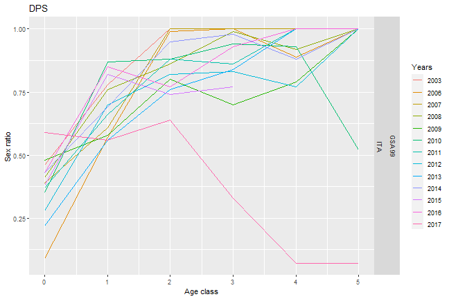

```r
results[[2]]
```

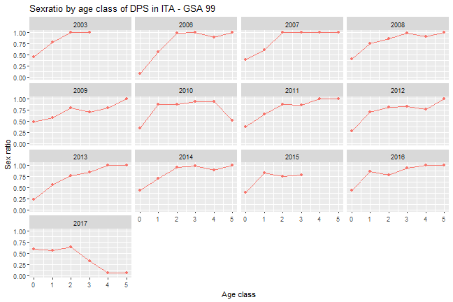

```r
results[[3]]
```

### SL_tab (sex ratio at length) table check

The function `MEDBS_SL_check` allows to check the sex ratio at length (SL) table providing a summary table of the data coverage for the selected species of the proportion of sex ratio for length class by year.

```r
results <- MEDBS_SL_check(SL_tab_example,"DPS","ITA","GSA 99")
results[[1]]
```

```
#>    COUNTRY    GSA START_YEAR END_YEAR SPECIES COUNT
#> 1      ITA GSA 99       2003     2005     DPS    30
#> 2      ITA GSA 99       2006     2006     DPS    29
#> 3      ITA GSA 99       2007     2007     DPS    29
#> 4      ITA GSA 99       2008     2008     DPS    32
#> 5      ITA GSA 99       2009     2009     DPS    40
#> 6      ITA GSA 99       2010     2010     DPS    39
#> 7      ITA GSA 99       2011     2011     DPS    40
#> 8      ITA GSA 99       2012     2012     DPS    35
#> 9      ITA GSA 99       2013     2013     DPS    37
#> 10     ITA GSA 99       2014     2014     DPS    37
#> 11     ITA GSA 99       2015     2015     DPS    32
#> 12     ITA GSA 99       2016     2016     DPS    37
#> 13     ITA GSA 99       2017     2017     DPS    37
```

Plots for the selected species of the proportion of sex ratio for length class by year are returned.

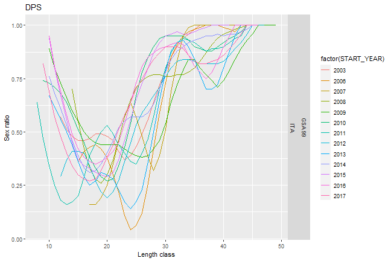

```r
results[[2]]
```

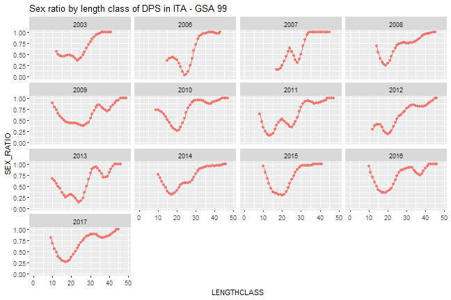

```r
results[[3]]
```

# Checks on FDI tables

## Table A

### Check empty fields in FDI A table

```r
check_EF_FDI_A(fdi_a_catch, verbose=FALSE)[[1]]
```

```
#>           country              year           quarter     vessel_length
#>                 0                 0                 0                 0
#>      fishing_tech         gear_type target_assemblage   mesh_size_range
#>                 0                 0                 0               446
#>            metier   domain_discards   domain_landings      supra_region
#>                 0                 0                 0                 0
#>        sub_region     eez_indicator     geo_indicator       specon_tech
#>                 0              2413                 0                 3
#>              deep           species      totwghtlandg       totvallandg
#>                 0                 0                30                33
#>          discards      confidential
#>                 0                 0
```

The second list's object gives the index of each NA in the reference column.

```r
check_EF_FDI_A(fdi_a_catch, verbose=FALSE)[[2]]
```

```
#> $country
#> integer(0)
#>
#> $year
#> integer(0)
#>
#> $quarter
#> integer(0)
#>
#> $vessel_length
#> integer(0)
#>
#> $fishing_tech
#> integer(0)
#>
```

[output cut: 254 more lines]

### Check duplicated records in FDI A table

The function `check_RD_FDI_A` check the presence of duplicated records. In particular, it checks whether the combination of the first 19 columns generates duplicate records. The function returns the indices of the duplicated rows.

```r
check_RD_FDI_A(fdi_a_catch)
```

```
#> 2 record/s duplicated
#> [1] 153 641
```

### Coverage of data by GSA and year in table A

The function `FDI_coverage` returns a data frame reporting the coverage of the selected table in terms of number of records by country, GSA and year. The function works on FDI tables A, G, H, I and J.

```r
FDI_coverage(data=fdi_a_catch, MS="PSP", verbose = FALSE)
```

```
#>   year country   gsa records
#> 1 2014     PSP GSA99     429
#> 2 2015     PSP GSA99     258
#> 3 2016     PSP GSA99     258
#> 4 2017     PSP GSA99     301
#> 5 2018     PSP GSA99     387
#> 6 2019     PSP GSA99     430
#> 7 2020     PSP GSA99     387
```

### Coverage of FDI discard data

The functions checks the discard coverage in table A for the selected MS by GSAs

```r
FDI_disc_coverage(fdi_a_catch, MS="PSP",GSA="GSA99",SP="HKE", verbose=TRUE)
```

```
#>   year   gsa Total_lands Lands_(disc > 0) % Lands_(disc >0) Lands_(disc = 0)
#> 1 2014 GSA99       1.099            0.305            27.75%            0.192
#> 2 2015 GSA99       0.249            0.000                 0            0.000
#> 3 2016 GSA99       0.152            0.110            72.37%            0.000
#> 4 2017 GSA99       0.088            0.000                 0            0.032
#> 5 2018 GSA99      33.917            0.000                 0            0.046
#> 6 2019 GSA99      33.907            0.044             0.13%            0.000
#> 7 2020 GSA99       0.485            0.000                 0            0.000
#>   % Lands_(disc = 0) Lands_(disc = NK) % Lands_(disc = NK)
#> 1             17.47%             0.602              54.78%
#> 2                  0             0.249             100.00%
#> 3                  0             0.042              27.63%
#> 4             36.36%             0.056              63.64%
#> 5              0.14%            33.871              99.86%
#> 6                  0            33.863              99.87%
#> 7                  0             0.485             100.00%
```

### Check number of record in FDI A table

The function checks and count the numbers of records data in the given table A grouped by year, GSA, MS, species, vessels length, and fishing techniques for three variables (Total live weight landed (ton), total value of landings (euro), and total discards (ton)). If SP, Vessel length, and fishing technique are not specified by the user the function combines those by default.

```r
head(FDI_cov_tableA(data=fdi_a_catch, SP="MUT", MS="PSP",fishtech=unique(fdi_a_catch$fishing_tech), GSA="GSA99")[[1]])
```

```
#>   year sub_region country species vessel_length fishing_tech totwghtlandg
#> 1 2014      GSA99     PSP     MUT      COMBINED          DFN            4
#> 2 2014      GSA99     PSP     MUT      COMBINED          DRB            1
#> 3 2015      GSA99     PSP     MUT      COMBINED          DFN            1
#> 4 2015      GSA99     PSP     MUT      COMBINED          DTS            2
#> 5 2015      GSA99     PSP     MUT      COMBINED          PMP            1
#> 6 2016      GSA99     PSP     MUT      COMBINED          DTS            1
#>   totvallandg discards
#> 1           4        0
#> 2           1        0
#> 3           1        1
#> 4           2        2
#> 5           1        1
#> 6           1        0
```

The function also provides a summary tables of the sum of the values grouped by year, GSA, MS, species, vessels length, and fishing techniques for same three variables (Total live weight landed (ton), total value of landings (euro), and total discards (ton)).

```r
head(FDI_cov_tableA(data=fdi_a_catch, SP="MUT", MS="PSP",fishtech=unique(fdi_a_catch$fishing_tech), GSA="GSA99")[[2]])
```

```
#>   year sub_region country species vessel_length fishing_tech totwghtlandg
#> 1 2014      GSA99     PSP     MUT      COMBINED          DFN        2.222
#> 2 2014      GSA99     PSP     MUT      COMBINED          DRB        0.035
#> 3 2015      GSA99     PSP     MUT      COMBINED          DFN        0.002
#> 4 2015      GSA99     PSP     MUT      COMBINED          DTS        0.224
#> 5 2015      GSA99     PSP     MUT      COMBINED          PMP        0.017
#> 6 2016      GSA99     PSP     MUT      COMBINED          DTS        0.014
#>   totvallandg discards
#> 1  1150.56688    0.000
#> 2   348.01141    0.000
#> 3    13.73272    0.000
#> 4  4050.27014    0.003
#> 5   116.72815    0.000
#> 6   139.20457    0.000
```

A plot for each of the three metrics is also provided:

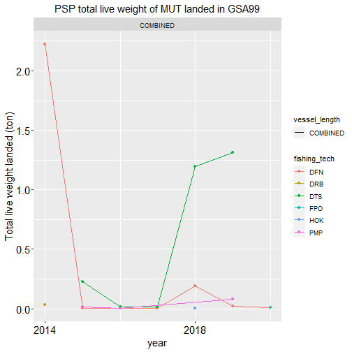

```r
FDI_cov_tableA(data=fdi_a_catch, SP="MUT", MS="PSP",fishtech=unique(fdi_a_catch$fishing_tech), GSA="GSA99")[[3]]
```

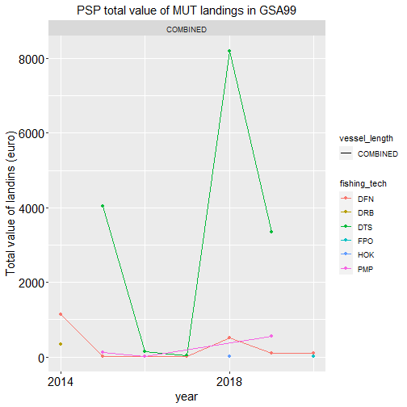

```r
FDI_cov_tableA(data=fdi_a_catch, SP="MUT", MS="PSP",fishtech=unique(fdi_a_catch$fishing_tech), GSA="GSA99")[[4]]
```

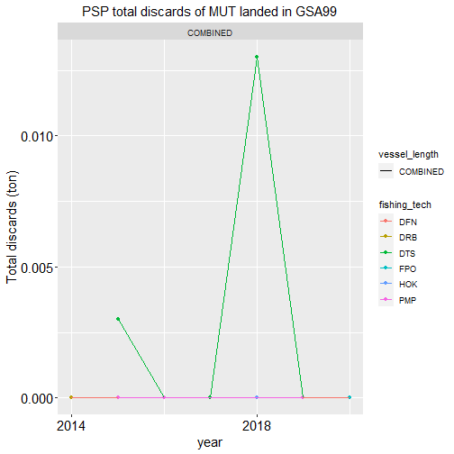

```r
FDI_cov_tableA(data=fdi_a_catch, SP="MUT", MS="PSP",fishtech=unique(fdi_a_catch$fishing_tech), GSA="GSA99")[[5]]
```

### Check of species value

The function estimates from the FDI table A an average price per species and year and compares it with average price calculated per country and species. Furthermore, the function performs comparisons between total weight landings and total value landings. In particular it identifies the cases with total landings > 0 but landings value = 0. In case SP parameter is not specified, the analysis is conducted over all the species in the provided data frame.

```r
FDI_prices_not_null(data = fdi_a_catch, MS = "PSP", GSA = "GSA99",SP = c("HKE"), verbose = FALSE)[[1]]
```

```
#>   species year land weight land value    price av_price
#> 1     HKE 2014       1.099  7607.1731 6.921905 4.596886
#> 2     HKE 2015       0.249  1944.6006 7.809641 4.596886
#> 3     HKE 2016       0.152   709.8665 4.670174 4.596886
#> 4     HKE 2017       0.088   495.4508 5.630123 4.596886
#> 5     HKE 2018      33.917 41572.5541 1.225714 4.596886
#> 6     HKE 2019      33.907 44517.1845 1.312920 4.596886
#> 7     HKE 2020       0.485  2234.7473 4.607726 4.596886
```

Furthermore, the function performs comparisons between total weight landings and total value landings. In particular it identifies the cases with total landings > 0 but landings value = 0. In case SP parameter is not specified, the analysis is conducted over all the species in the provided data frame.

```r
FDI_prices_not_null(data = fdi_a_catch, MS = "PSP", GSA = "GSA99",SP = c("HKE"), verbose = TRUE)[[2]]
```

```
#> [1] "Average price per species in PSP"
#> No cases with total landings > 0 but landings value = 0
#> [1] year        species     land weight land value  price
#> <0 righe> (o 0-length row.names)
```

### Check prices trend in FDI A table

The function checks the trend prices in the given table grouped by year, GSA, MS, and species. If SP are not specified by the user the function combines those by default.

```r
FDI_prices_cov(data = fdi_a_catch, SP = c("HKE"), MS = "PSP", GSA = "GSA99",verbose=FALSE)[[1]]
```

```
#>   year country sub_region species totwghtlandg totvallandg mean_price
#> 1 2014     PSP      GSA99     HKE        1.099   7607.1731   6.921905
#> 2 2015     PSP      GSA99     HKE        0.249   1944.6006   7.809641
#> 3 2016     PSP      GSA99     HKE        0.152    709.8665   4.670174
#> 4 2017     PSP      GSA99     HKE        0.088    495.4508   5.630123
#> 5 2018     PSP      GSA99     HKE       33.917  41572.5541   1.225714
#> 6 2019     PSP      GSA99     HKE       33.907  44517.1845   1.312920
#> 7 2020     PSP      GSA99     HKE        0.485   2234.7473   4.607726
```

```r
FDI_prices_cov(data = fdi_a_catch, SP = c("HKE"), MS = "PSP", GSA = "GSA99",verbose=FALSE)[[2]]
```

```
#>   year country sub_region species totwghtlandg totvallandg mean_price
#> 1 2014     PSP   COMBINED     HKE        1.099   7607.1731   6.921905
#> 2 2015     PSP   COMBINED     HKE        0.249   1944.6006   7.809641
#> 3 2016     PSP   COMBINED     HKE        0.152    709.8665   4.670174
#> 4 2017     PSP   COMBINED     HKE        0.088    495.4508   5.630123
#> 5 2018     PSP   COMBINED     HKE       33.917  41572.5541   1.225714
#> 6 2019     PSP   COMBINED     HKE       33.907  44517.1845   1.312920
#> 7 2020     PSP   COMBINED     HKE        0.485   2234.7473   4.607726
```

## Table G

### Check empty fields in FDI G table

The function `check_EF_FDI_G` checks the presence of not allowed empty data in the given table, according to the 'Fisheries Dependent Information data call 2021 - Annex 1'. A list is returned by the function. The first list's object is a vector containing the number of NA for each reference column.

```r
check_EF_FDI_G(fdi_g_effort, verbose=FALSE)[[1]]
```

```
#>           country              year           quarter     vessel_length
#>                 0                 0                 0                 0
#>      fishing_tech         gear_type target_assemblage   mesh_size_range
#>                 0                 0                 0               446
#>            metier      supra_region        sub_region     eez_indicator
#>                 0                 0                 0              2413
#>     geo_indicator       specon_tech              deep        totseadays
#>                 0                 0                 0                 0
#>    totkwdaysatsea    totgtdaysatsea       totfishdays     totkwfishdays
#>                 0                18                18                79
#>     totgtfishdays             hrsea           kwhrsea           gthrsea
#>               103                18                18                18
#>            totves      confidential
#>                 0                 0
```

The second list's object gives the index of each NA in the reference column.

```r
check_EF_FDI_G(fdi_g_effort, verbose=FALSE)[[2]]
```

```
#> $country
#> integer(0)
#>
#> $year
#> integer(0)
#>
#> $quarter
#> integer(0)
#>
#> $vessel_length
#> integer(0)
#>
#> $fishing_tech
#> integer(0)
#>
```

[output cut: 274 more lines]

### Check duplicated records in FDI G table

The function `check_RD_FDI_G` check the presence of duplicated records. In particular, it checks whether the combination of the first 15 columns generates duplicate records. The function returns the indices of the duplicated rows.

```r
head(check_RD_FDI_G(fdi_g_effort))
```

```
#> 668 record/s duplicated
#> [1] 42 43 44 45 46 52
```

### Coverage of data by GSA and year in table G

The function `FDI_coverage` returns a data frame reporting the coverage of the selected table in terms of number of records by country, GSA and year. The function work on FDI tables A, G, H, I and J.

```r
FDI_coverage(data=fdi_g_effort,MS="PSP", verbose = FALSE)
```

```
#>   year country   gsa records
#> 1 2014     PSP GSA99     429
#> 2 2015     PSP GSA99     258
#> 3 2016     PSP GSA99     258
#> 4 2017     PSP GSA99     301
#> 5 2018     PSP GSA99     387
#> 6 2019     PSP GSA99     430
#> 7 2020     PSP GSA99     387
```

### Check number of record in FDI G table

The function checks and count the numbers of records data in the given table grouped by year, GSA, MS, vessels length, fishing techniques, and metier for the following 8 variables: Total days at sea; Total Fishing Days; Total kW days at Sea; total GT days at sea; Total kW fishing days; totgtfishdays; Hours at Sea; kW hours at sea. If Vessel length, fishing technique, and metier are not specified by the user the function combines those by default.

```r
FDI_cov_tableG(data=fdi_g_effort, MS="PSP", GSA="GSA99")[[1]]
```

```
#>   year sub_region country vessel_length fishing_tech   metier totseadays
#> 1 2014      GSA99     PSP      COMBINED     COMBINED COMBINED        429
#> 2 2015      GSA99     PSP      COMBINED     COMBINED COMBINED        258
#> 3 2016      GSA99     PSP      COMBINED     COMBINED COMBINED        258
#> 4 2017      GSA99     PSP      COMBINED     COMBINED COMBINED        301
#> 5 2018      GSA99     PSP      COMBINED     COMBINED COMBINED        387
#> 6 2019      GSA99     PSP      COMBINED     COMBINED COMBINED        430
#> 7 2020      GSA99     PSP      COMBINED     COMBINED COMBINED        387
#>   totfishdays totkwdaysatsea totgtdaysatsea totkwfishdays totgtfishdays hrsea
#> 1         421            429            421           417           419   398
#> 2         252            258            252           248           252   244
#> 3         258            258            258           234           244   243
#> 4         301            301            301           288           290   291
#> 5         387            387            387           368           385   357
#> 6         430            430            430           411           401   393
#> 7         383            387            383           373           364   360
#>   kwhrsea
#> 1     398
#> 2     244
#> 3     243
#> 4     291
#> 5     357
#> 6     393
#> 7     360
```

```r
FDI_cov_tableG(data=fdi_g_effort, MS="PSP", GSA="GSA99")[[2]]
```

```
#>   year sub_region country vessel_length fishing_tech   metier totseadays
#> 1 2014      GSA99     PSP      COMBINED     COMBINED COMBINED      43774
#> 2 2015      GSA99     PSP      COMBINED     COMBINED COMBINED      33808
#> 3 2016      GSA99     PSP      COMBINED     COMBINED COMBINED      30133
#> 4 2017      GSA99     PSP      COMBINED     COMBINED COMBINED      30792
#> 5 2018      GSA99     PSP      COMBINED     COMBINED COMBINED      27531
#> 6 2019      GSA99     PSP      COMBINED     COMBINED COMBINED      54994
#> 7 2020      GSA99     PSP      COMBINED     COMBINED COMBINED      47260
#>   totfishdays totkwdaysatsea totgtdaysatsea totkwfishdays totgtfishdays  hrsea
#> 1   1167896.7          43173        4409290            NA            NA     NA
#> 2   1055410.4          33101        3525484            NA            NA     NA
#> 3    831831.1          29250        3672117       2878550      779545.5 304445
#> 4    586293.7          30399        2474672       2394149      563031.3 386703
#> 5    777467.5          26995        3215308       3069861      746276.9 311062
#> 6   1249878.1          54537        4834741       4647969     1188048.0 300004
#> 7   1643316.1          46697        5665237            NA            NA     NA
#>    kwhrsea
#> 1       NA
#> 2       NA
#> 3 62946924
#> 4 96712548
#> 5 62348605
#> 6 49104568
#> 7       NA
```

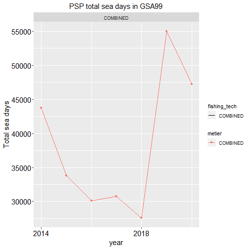

```r
FDI_cov_tableG(data=fdi_g_effort, MS="PSP", GSA="GSA99")[[3]]
```

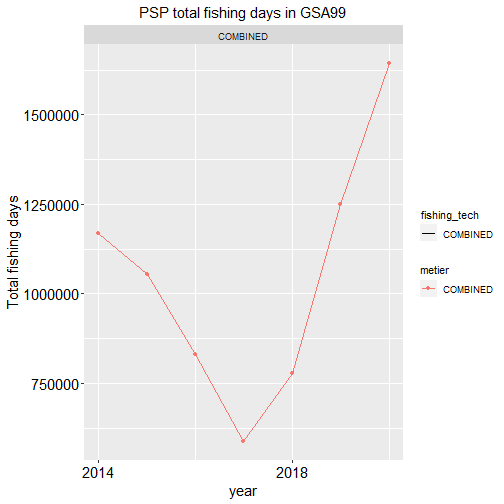

```r
FDI_cov_tableG(data=fdi_g_effort, MS="PSP", GSA="GSA99")[[4]]
```

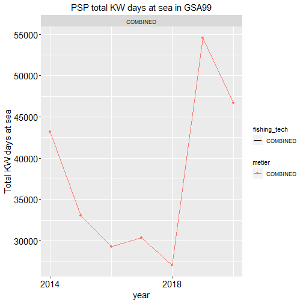

```r
FDI_cov_tableG(data=fdi_g_effort, MS="PSP", GSA="GSA99")[[5]]
```

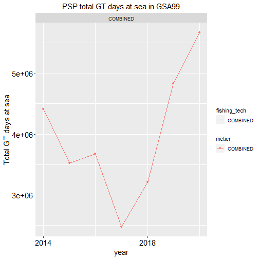

```r
FDI_cov_tableG(data=fdi_g_effort, MS="PSP", GSA="GSA99")[[6]]
```

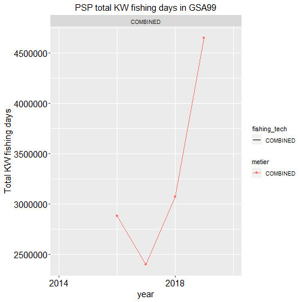

```r
FDI_cov_tableG(data=fdi_g_effort, MS="PSP", GSA="GSA99")[[7]]
```

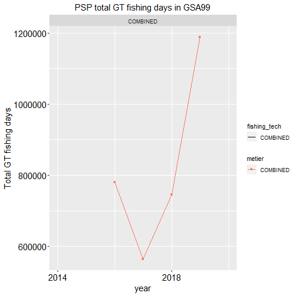

```r
FDI_cov_tableG(data=fdi_g_effort, MS="PSP", GSA="GSA99")[[8]]
```

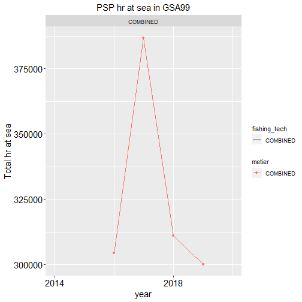

```r
FDI_cov_tableG(data=fdi_g_effort, MS="PSP", GSA="GSA99")[[9]]
```

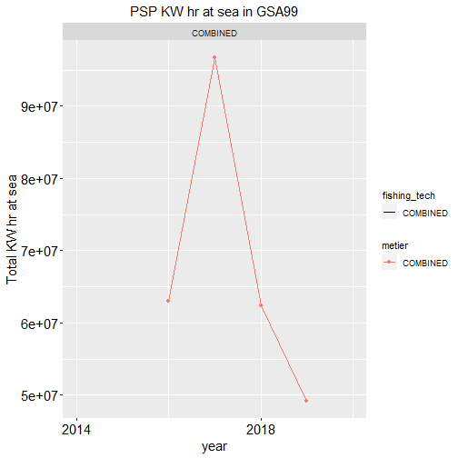

```r
FDI_cov_tableG(data=fdi_g_effort, MS="PSP", GSA="GSA99")[[10]]
```

## Table H

### Check empty fields in FDI H table

The function `check_EF_FDI_H` checks the presence of not allowed empty data in the given table, according to the 'Fisheries Dependent Information data call 2021 - Annex 1'. A list is returned by the function. The first list's object is a vector containing the number of NA for each reference column.

```r
check_EF_FDI_H(fdi_h_spatial_landings, verbose=FALSE)[[1]]
```

```
#>           country              year           quarter     vessel_length
#>                 0                 0                 0                 0
#>      fishing_tech         gear_type target_assemblage   mesh_size_range
#>                 0                 0               446                 0
#>            metier      supra_region        sub_region     eez_indicator
#>                 0                 0                 0                 0
#>     geo_indicator       specon_tech              deep    rectangle_type
#>                 0              1138              2426                 0
#>     rectangle_lat     rectangle_lon          c_square           species
#>                 0                 0                 0                 0
#>      totwghtlandg       totvallandg      confidential
#>                 0                 0              2450
```

The second list's object gives the index of each NA in the reference column.

```r
check_EF_FDI_H(fdi_h_spatial_landings, verbose=FALSE)[[2]]
```

```
#> $country
#> integer(0)
#>
#> $year
#> integer(0)
#>
#> $quarter
#> integer(0)
#>
#> $vessel_length
#> integer(0)
#>
#> $fishing_tech
#> integer(0)
#>
```

[output cut: 510 more lines]

### Check duplicated records in FDI H table

The function `check_RD_FDI_H` check the presence of duplicated records. In particular, it checks whether the combination of the first 15 columns generates duplicate records. The function returns the indices of the duplicated rows.

```r
h_spatial_land <- rbind(fdi_h_spatial_landings,fdi_h_spatial_landings[1,])
check_RD_FDI_H(h_spatial_land)
```

```
#> 22 record/s duplicated
#>  [1]  853  881  887  888  923  924 1091 1111 1122 1161 1325 1371 1389 1420 1421
#> [16] 1422 1453 1479 1481 1499 2366 2451
```

### Coverage of data by GSA and year in table H

The function `FDI_coverage` returns a data frame reporting the coverage of the selected table in terms of number of records by country, GSA and year. The function work on FDI tables A, G, H, I and J.

```r
FDI_coverage(data=fdi_h_spatial_landings ,MS="PSP", verbose = FALSE)
```

```
#>   year country   gsa records
#> 1 2014     PSP GSA99     429
#> 2 2015     PSP GSA99     258
#> 3 2016     PSP GSA99     258
#> 4 2017     PSP GSA99     301
#> 5 2018     PSP GSA99     387
#> 6 2019     PSP GSA99     430
#> 7 2020     PSP GSA99     387
```

### check NA values in spatial columns of table H

The function checks the incorrect combination of NA in the spatial columns in both table H (Landings by rectangle) and table I (Effort by rectangle). The following check are included:

- presence of NA values in 'c_square' field when 'rectangle_type', 'rectangle_lat', 'rectangle_lon' are all NA
- the presence any data in 'rectangle_type', 'rectangle_lat', 'rectangle_lon' when 'c_square' is reported
- the presence of any data in 'c-squares' when 'rectangle_type', 'rectangle_lat', 'rectangle_lon' are filled in

Furthermore the function identifies the records without any sub-region assignment.

```r
head(FDI_checks_spatial_HI(data=fdi_h_spatial_landings,MS="PSP", verbose=TRUE)[[1]])
```

```
#> no NAs in 'c_square' field when 'rectangle_type', 'rectangle_lat', 'rectangle_lon' are all NA
#> 2450  record with at least one data among 'rectangle_type', 'rectangle_lat', 'rectangle_lon' when 'c_square' is reported
#> no data reported in 'c-squares' when 'rectangle_type', 'rectangle_lat', 'rectangle_lon' are filled in
#> 0 record/s with 'NK' values in 'sub_region' field
#> 0 record/s with 'NA' values in 'sub_region' field
#>   country year quarter vessel_length fishing_tech gear_type target_assemblage
#> 1     PSP 2014       1            NK          DTS       OTB                NK
#> 2     PSP 2014       2            NK          DTS       OTB                NK
#> 3     PSP 2014       3            NK          DTS       OTB                NK
#> 4     PSP 2014       1        VL0006          DRB       DRB              <NA>
#> 5     PSP 2014       4        VL0612          PMP       DRB              <NA>
#> 6     PSP 2014       1        VL1218          PMP       DRB              <NA>
#>   mesh_size_range           metier supra_region sub_region rectangle_type
#> 1             DEF OTB_DEF_>=40_0_0          OFR      GSA99          05*05
#> 2             DEF OTB_DEF_>=40_0_0          OFR      GSA99          05*05
#> 3             DWS OTB_DWS_>=40_0_0          OFR      GSA99          05*05
#> 4             MOL    DRB_MOL_0_0_0          OFR      GSA99          05*05
#> 5             MOL    DRB_MOL_0_0_0          MBS      GSA99          05*05
#> 6             MOL    DRB_MOL_0_0_0          MBS      GSA99          05*05
#>   rectangle_lat rectangle_lon   c_square
#> 1            NA            NA 1000:100:1
#> 2            NA            NA 1000:100:2
#> 3            NA            NA 1000:100:2
#> 4            NA            NA 1000:100:3
#> 5            NA            NA 1000:100:1
#> 6            NA            NA 1000:100:1
```

```r
FDI_checks_spatial_HI(data=fdi_h_spatial_landings,MS="PSP", verbose=FALSE)[[2]]
```

```
#>  [1] country           year              quarter           vessel_length
#>  [5] fishing_tech      gear_type         target_assemblage mesh_size_range
#>  [9] metier            supra_region      sub_region
#> <0 righe> (o 0-length row.names)
```

### Compatibility of the geographical coordinates with rectangle type

The function checks in both tables H and I the compatibility of the geographical coordinates (latitude and longitude) with the value provided for the rectangle type. The data frame of the input table is returned retaining the only records in which at least one among latitude and longitude is not compatible with the rectangle type. Two more columns (lat.check and lon.check) are included to the data frame to report the results of the checks respectively for latitude and longitude.

```r
FDI_check_coord(data=fdi_i_spatial_effort, MS="PSP",verbose=TRUE)
```

```
#> no data with rectangle coordinates available in the selected table
#> NULL
```

## Table I

### Check empty fields in FDI I table

The function `check_EF_FDI_I` checks the presence of not allowed empty data in the given table, according to the 'Fisheries Dependent Information data call 2021 - Annex 1'. A list is returned by the function. The first list's object is a vector containing the number of NA for each reference column.

```r
check_EF_FDI_I(fdi_i_spatial_effort,verbose=FALSE)[[1]]
```

```
#>           country              year           quarter     vessel_length
#>                 0                 0                 0                 0
#>      fishing_tech         gear_type target_assemblage   mesh_size_range
#>                 0                 0               446                 0
#>            metier      supra_region        sub_region     eez_indicator
#>                 0                 0                 0                 0
#>     geo_indicator       specon_tech              deep    rectangle_type
#>                 0              1138              2436                 0
#>     rectangle_lat     rectangle_lon          c_square       totfishdays
#>                 0                 0                 0                 0
#>      confidential
#>                 0
```

The second list's object gives the index of each NA in the reference column.

```r
check_EF_FDI_I(fdi_i_spatial_effort,verbose=FALSE)[[2]]
```

```
#> $country
#> integer(0)
#>
#> $year
#> integer(0)
#>
#> $quarter
#> integer(0)
#>
#> $vessel_length
#> integer(0)
#>
#> $fishing_tech
#> integer(0)
#>
```

[output cut: 330 more lines]

### Check duplicated records in FDI I table

The function `check_RD_FDI_I` check the presence of duplicated records. In particular, it checks whether the combination of the first 15 columns generates duplicate records. The function returns the indices of the duplicated rows.

```r
i_spatial_fe <- rbind(fdi_i_spatial_effort,fdi_i_spatial_effort[1,])
head(check_RD_FDI_I(i_spatial_fe))
```

```
#> 150 record/s duplicated
#> [1] 44 45 53 54 55 61
```

### Coverage of data by GSA and year in table I

The function `FDI_coverage` returns a data frame reporting the coverage of the selected table in terms of number of records by country, GSA and year. The function work on FDI tables A, G, H, I and J.

```r
FDI_coverage(data=fdi_i_spatial_effort ,MS="PSP", verbose = FALSE)
```

```
#>   year country   gsa records
#> 1 2014     PSP GSA99     429
#> 2 2015     PSP GSA99     258
#> 3 2016     PSP GSA99     258
#> 4 2017     PSP GSA99     301
#> 5 2018     PSP GSA99     387
#> 6 2019     PSP GSA99     430
#> 7 2020     PSP GSA99     387
```

### check NA values in spatial columns of table I

The function checks the incorrect combination of NA in the spatial columns in both table H (Landings by rectangle) and table I (Effort by rectangle). The following check are included:

- presence of NA values in 'c_square' field when 'rectangle_type', 'rectangle_lat', 'rectangle_lon' are all NA
- the presence any data in 'rectangle_type', 'rectangle_lat', 'rectangle_lon' when 'c_square' is reported
- the presence of any data in 'c-squares' when 'rectangle_type', 'rectangle_lat', 'rectangle_lon' are filled in

Furthermore, the function identifies the records without any sub-region assignment.

```r
head(FDI_checks_spatial_HI(data=fdi_i_spatial_effort,MS="PSP", verbose=TRUE)[[1]])
```

```
#> no NAs in 'c_square' field when 'rectangle_type', 'rectangle_lat', 'rectangle_lon' are all NA
#> 2450  record with at least one data among 'rectangle_type', 'rectangle_lat', 'rectangle_lon' when 'c_square' is reported
#> no data reported in 'c-squares' when 'rectangle_type', 'rectangle_lat', 'rectangle_lon' are filled in
#> 0 record/s with 'NK' values in 'sub_region' field
#> 0 record/s with 'NA' values in 'sub_region' field
#>   country year quarter vessel_length fishing_tech gear_type target_assemblage
#> 1     PSP 2014       1            NK          DTS       OTB                NK
#> 2     PSP 2014       2            NK          DTS       OTB                NK
#> 3     PSP 2014       3            NK          DTS       OTB                NK
#> 4     PSP 2014       1        VL0006          DRB       DRB              <NA>
#> 5     PSP 2014       4        VL0612          PMP       DRB              <NA>
#> 6     PSP 2014       1        VL1218          PMP       DRB              <NA>
#>   mesh_size_range           metier supra_region sub_region rectangle_type
#> 1             DEF OTB_DEF_>=40_0_0          OFR      GSA99          05*05
#> 2             DEF OTB_DEF_>=40_0_0          OFR      GSA99          05*05
#> 3             DWS OTB_DWS_>=40_0_0          OFR      GSA99          05*05
#> 4             MOL    DRB_MOL_0_0_0          OFR      GSA99          05*05
#> 5             MOL    DRB_MOL_0_0_0          MBS      GSA99          05*05
#> 6             MOL    DRB_MOL_0_0_0          MBS      GSA99          05*05
#>   rectangle_lat rectangle_lon   c_square
#> 1            NA            NA 1000:100:1
#> 2            NA            NA 1000:100:2
#> 3            NA            NA 1000:100:2
#> 4            NA            NA 1000:100:3
#> 5            NA            NA 1000:100:1
#> 6            NA            NA 1000:100:1
```

```r
FDI_checks_spatial_HI(data=fdi_i_spatial_effort,MS="PSP", verbose=FALSE)[[2]]
```

```
#>  [1] country           year              quarter           vessel_length
#>  [5] fishing_tech      gear_type         target_assemblage mesh_size_range
#>  [9] metier            supra_region      sub_region
#> <0 righe> (o 0-length row.names)
```

### Compatibility of the geographical coordinates with rectangle type

The function checks in both tables H and I the compatibility of the geographical coordinates (latitude and longitude) with the value provided for the rectangle type. The data frame of the input table is returned retaining the only records in which at least one among latitude and longitude is not compatible with the rectangle type. Two more columns (lat.check and lon.check) are included to the data frame to report the results of the checks respectively for latitude and longitude.

```r
FDI_check_coord(data=fdi_i_spatial_effort, MS="PSP",verbose=TRUE)
```

```
#> no data with rectangle coordinates available in the selected table
#> NULL
```

## Table J

### Check empty fields in FDI J table

The function `check_EF_FDI_J` checks the presence of not allowed empty data in the given table, according to the Fisheries Dependent Information data call 2021 - Annex 1. A list is returned by the function. The first list's object is a vector containing the number of NA for each reference column.

```r
check_EF_FDI_J(fdi_j_capacity, verbose=FALSE)[[1]]
```

```
#>              country                 year        vessel_length
#>                    0                    0                    0
#>         fishing_tech         supra_region        geo_indicator
#>                    0                    0                    0
#> principal_sub_region             tottrips                totkw
#>                    0                    0                    0
#>                totgt               totves               avgage
#>                    0                    0                    0
#>               avgloa           maxseadays
#>                    0                    0
```

The second list's object gives the index of each NA in the reference column.

```r
check_EF_FDI_J(fdi_j_capacity, verbose=FALSE)[[2]]
```

```
#> $country
#> integer(0)
#>
#> $year
#> integer(0)
#>
#> $vessel_length
#> integer(0)
#>
#> $fishing_tech
#> integer(0)
#>
#> $supra_region
#> integer(0)
#>
#> $geo_indicator
#> integer(0)
#>
#> $principal_sub_region
#> integer(0)
#>
#> $tottrips
#> integer(0)
#>
#> $totkw
#> integer(0)
#>
#> $totgt
#> integer(0)
#>
#> $totves
#> integer(0)
#>
#> $avgage
#> integer(0)
#>
#> $avgloa
#> integer(0)
#>
#> $maxseadays
#> integer(0)
```

### Check duplicated records in FDI J table

The function `check_RD_FDI_J` check the presence of duplicated records. In particular, it checks whether the combination of the first 15 columns generates duplicate records. The function returns the indices of the duplicated rows.

```r
j_capacity <- rbind(fdi_j_capacity,fdi_j_capacity[1,])
head(check_RD_FDI_J(j_capacity))
```

```
#> 2239 record/s duplicated
#> [1]  2  3 14 22 33 34
```

### Coverage of data by GSA and year in table J

The function `FDI_coverage` returns a data frame reporting the coverage of the selected table in terms of number of records by country, GSA and year. The function work on FDI tables A, G, H, I and J.

```r
FDI_coverage(data=fdi_j_capacity ,MS="PSP", verbose = FALSE)
```

```
#>   year country   gsa records
#> 1 2014     PSP GSA99     429
#> 2 2015     PSP GSA99     258
#> 3 2016     PSP GSA99     258
#> 4 2017     PSP GSA99     301
#> 5 2018     PSP GSA99     387
#> 6 2019     PSP GSA99     430
#> 7 2020     PSP GSA99     387
```

### Check of vessel lenght in FDI table J

The function checks the average vessels length with the vessel length category (table J). A list of two data frames is returned. The first reports the cases with NAs in either vessel length or vessel category or both, while the second table reports the cases in which vessel length does not match vessel length category.

```r
head(FDI_vessel_lenth(data=fdi_j_capacity, MS="PSP", verbose = TRUE)[[1]])
```

```
#> [1] "Check consistency of vessel length with vessel category in table J for PSP data"
#> found 30 cases with NAs in either vessel length or vessel category or both. Check output table
#> found 1991 cases where vessel length does not match vessel length category
#>    country year vessel_length principal_sub_region totkw totgt totves    avgage
#> 1      PSP 2014            NK                GSA99   221    21      1   7.00000
#> 2      PSP 2014            NK                GSA99   471    18      1 444.00000
#> 3      PSP 2014            NK                GSA99   441    45     44  15.00000
#> 20     PSP 2016            NK                GSA99   547   108      3  49.66667
#> 21     PSP 2017            NK                GSA99   818   200      2  44.00000
#> 22     PSP 2017            NK                GSA99  2213   854      7  18.71429
#>     avgloa consistent
#> 1   11.780         NA
#> 2   12.680         NA
#> 3  444.000         NA
#> 20 444.000         NA
#> 21  21.305         NA
#> 22  23.370         NA
```

```r
head(FDI_vessel_lenth(data=fdi_j_capacity, MS="PSP", verbose = TRUE)[[2]])
```

```
#> [1] "Check consistency of vessel length with vessel category in table J for PSP data"
#> found 30 cases with NAs in either vessel length or vessel category or both. Check output table
#> found 1991 cases where vessel length does not match vessel length category
#>    country year vessel_length principal_sub_region totkw totgt totves
#> 4      PSP 2014        VL0006                GSA99   444   108      3
#> 5      PSP 2014        VL0612                GSA99   598    44     44
#> 6      PSP 2014        VL1218                GSA99   219    68      1
#> 8      PSP 2014        VL2440                GSA99   444  1185     18
#> 9      PSP 2015        VL0006                GSA99  1326    44      6
#> 10     PSP 2015        VL0612                GSA99  1181   385      1
#>        avgage   avgloa consistent
#> 4  4444.00000 16.93333      FALSE
#> 5    14.00000 21.53000      FALSE
#> 6    27.00000 20.04000      FALSE
#> 8    36.55556 21.63611      FALSE
#> 9    44.00000 44.00000      FALSE
#> 10   14.00000 37.81000      FALSE
```

### Check number of record in FDI J table

- total trips
- total kW
- total GT
- total vessels

```r
FDI_cov_tableJ(data=fdi_j_capacity, MS="PSP", GSA="GSA99", verbose=TRUE)[[1]]
```

```
#>   year principal_sub_region country vessel_length fishing_tech total_trips
#> 1 2014                GSA99     PSP      COMBINED     COMBINED         420
#> 2 2015                GSA99     PSP      COMBINED     COMBINED         250
#> 3 2016                GSA99     PSP      COMBINED     COMBINED         252
#> 4 2017                GSA99     PSP      COMBINED     COMBINED         294
#> 5 2018                GSA99     PSP      COMBINED     COMBINED         378
#> 6 2019                GSA99     PSP      COMBINED     COMBINED         423
#> 7 2020                GSA99     PSP      COMBINED     COMBINED         377
#>   total_total_kW total_GT total_vessels
#> 1            429      429           429
#> 2            258      258           258
#> 3            258      258           258
#> 4            301      301           301
#> 5            387      387           387
#> 6            430      430           430
#> 7            387      387           387
```

```r
FDI_cov_tableJ(data=fdi_j_capacity, MS="PSP", GSA="GSA99", verbose=FALSE)[[2]]
```

```
#>   year principal_sub_region country vessel_length fishing_tech total_trips
#> 1 2014                GSA99     PSP      COMBINED     COMBINED    455248.3
#> 2 2015                GSA99     PSP      COMBINED     COMBINED    183594.9
#> 3 2016                GSA99     PSP      COMBINED     COMBINED    218005.7
#> 4 2017                GSA99     PSP      COMBINED     COMBINED    172220.7
#> 5 2018                GSA99     PSP      COMBINED     COMBINED    363788.8
#> 6 2019                GSA99     PSP      COMBINED     COMBINED    362471.2
#> 7 2020                GSA99     PSP      COMBINED     COMBINED    238462.8
#>   total_total_kW total_GT total_vessels
#> 1      1018449.9 271891.0       28929.0
#> 2       630518.2 219999.9       34332.0
#> 3       600032.3 171230.3        8761.0
#> 4       643223.7 233306.7        6079.0
#> 5       896454.6 334577.5       17438.0
#> 6      1217063.3 468387.0       19054.5
#> 7       878027.3 316756.3       19888.5
```

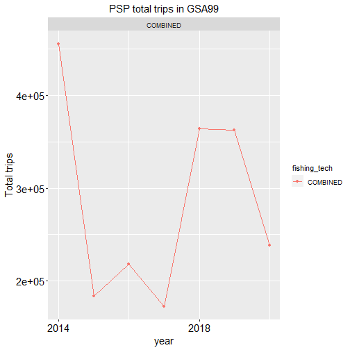

```r
FDI_cov_tableJ(data=fdi_j_capacity, MS="PSP", GSA="GSA99", verbose=FALSE)[[3]]
```

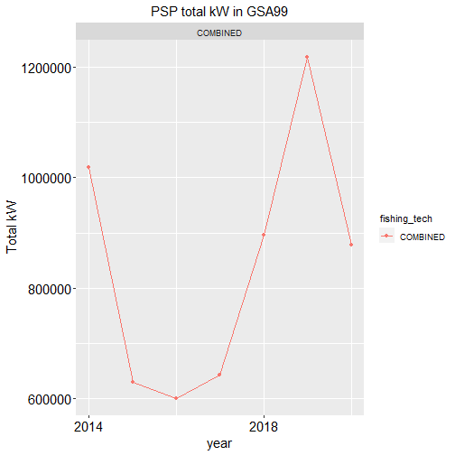

```r
FDI_cov_tableJ(data=fdi_j_capacity, MS="PSP", GSA="GSA99", verbose=FALSE)[[4]]
```

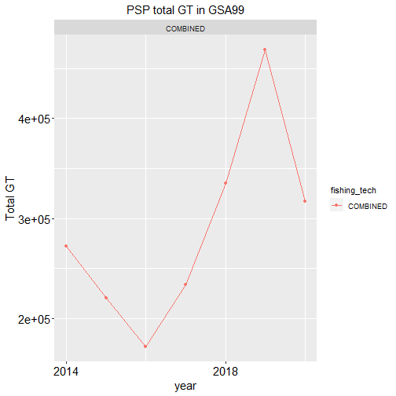

```r
FDI_cov_tableJ(data=fdi_j_capacity, MS="PSP", GSA="GSA99", verbose=FALSE)[[5]]
```

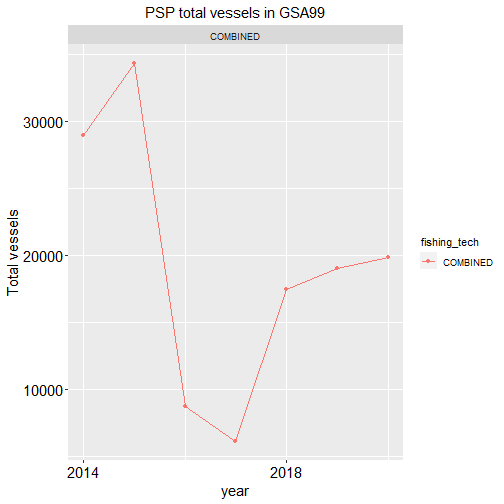

```r
FDI_cov_tableJ(data=fdi_j_capacity, MS="PSP", GSA="GSA99", verbose=FALSE)[[6]]
```

## Cross-checks

### Coverage comparison of totfishdays between FDI tables G and I

The function checks the coverage comparison of totfishdays in FDI tables G and I and returns a data frame of the comparison between the two tables.

```r
FDI_fishdays_cov (dataG=fdi_g_effort, dataI=fdi_i_spatial_effort, MS="PSP", verbose = TRUE)
```

```
#> [1] "Coverage of total fish days for PSP data in tables G and I"
#>   year country   gsa Total fish days table G Total fish days table I  % diff
#> 1 2014     PSP GSA99               1167896.7                1332.879 -99.89%
#> 2 2015     PSP GSA99               1055410.4                 781.721 -99.93%
#> 3 2016     PSP GSA99                831831.1                1238.866 -99.85%
#> 4 2017     PSP GSA99                586293.7                1050.782 -99.82%
#> 5 2018     PSP GSA99                777467.5                1379.131 -99.82%
#> 6 2019     PSP GSA99               1249878.1                1376.709 -99.89%
#> 7 2020     PSP GSA99               1643316.1                1371.771 -99.92%
```

### Coverage of weight of landings in FDI table A and H

The functions checks the coverage of weight of landings comparing data reported in table A and H and returns a data frame with the weight of landings by GSA and year.

```r
FDI_landweight_cov(dataA=fdi_a_catch, dataH=fdi_h_spatial_landings, MS="PSP", verbose = TRUE)
```

```
#> [1] "Coverage of landings' weight for PSP data in tables A and H"
#>   year country   gsa Lands table A Lands table H    % diff
#> 1 2014     PSP GSA99       265.910     10651.418  3905.65%
#> 2 2015     PSP GSA99       131.154      5372.477  3996.31%
#> 3 2016     PSP GSA99        41.679      5638.029 13427.27%
#> 4 2017     PSP GSA99        72.392      5266.220  7174.59%
#> 5 2018     PSP GSA99       125.115      6301.502  4936.57%
#> 6 2019     PSP GSA99       179.482      7191.640  3906.89%
#> 7 2020     PSP GSA99       225.216      8186.780  3535.08%
```

### Check number of vessels in FDI table J and G

The function cross-checks the number of vessels in table J in comparison of the number reported in table G. A list of data frames is returned. The first element reports the number of vessel in table J in comparison to table G and the relative difference percentage, while the second table reports the vessels not present in table G.

```r
FDI_vessel_numbers(dataJ=fdi_j_capacity, dataG=fdi_g_effort, MS="PSP", verbose = TRUE)
```

```
#> [1] "Comparing number of vessels in tables J and G for PSP"
#> $comparison_table_J_G
#>    year   gsa fish_tech  vesselsJ vesselsG     diff
#> 1  2014 GSA99       DFN 16795.000     1597   90.49%
#> 2  2014 GSA99       DRB    65.000       25   61.54%
#> 3  2014 GSA99       DTS  1090.000       85   92.20%
#> 4  2014 GSA99       FPO    31.000       23   25.81%
#> 5  2014 GSA99       HOK   773.000      480   37.90%
#> 6  2014 GSA99       PMP 10175.000      494   95.14%
#> 7  2015 GSA99       DFN 11690.000      647   94.47%
#> 8  2015 GSA99       DRB    32.000       51  -59.38%
#> 9  2015 GSA99       DTS   189.000       62   67.20%
#> 10 2015 GSA99       FPO    39.000       29   25.64%
#> 11 2015 GSA99       HOK 10183.000      147   98.56%
#> 12 2015 GSA99       PMP 12199.000      504   95.87%
```

[output cut: 33 more lines]

### Cross check between FDI tables A and G

The function checks the possible data inconsistency between landings and effort and returns a summary table where all the mismatches between landings and effort are reported.

```r
head(FDI_cross_checks_AG(data1=fdi_a_catch, data2=fdi_g_effort))
```

```
#>     country year quarter vessel_length fishing_tech gear_type target_assemblage
#> 18      PSP 2014       1        VL0006          DFN      <NA>              <NA>
#> 33      PSP 2014       1        VL0006          PMP      <NA>              <NA>
#> 48      PSP 2014       1        VL0612          DFN      <NA>              <NA>
#> 78      PSP 2014       1        VL1218          DFN      <NA>              <NA>
#> 138     PSP 2014       1        VL2440          DFN       GTR               SLP
#> 158     PSP 2014       1          <NA>          DTS       OTB               DEF
#>     mesh_size_range           metier sub_region totwghtlandg totfishdays
#> 18          100D400             <NA>      GSA99        0.000      648.07
#> 33             <NA>             <NA>      GSA99        0.001        0.00
#> 48            20D40             <NA>      GSA99        0.000        8.12
#> 78            20D40             <NA>      GSA99        0.000       56.84
#> 138            <NA> GNS_SLP_>=16_0_0      GSA99        0.000      317.41
#> 158            <NA> OTB_DEF_>=40_0_0      GSA99        0.000       22.04
#>     totseadays                                                   Check results
#> 18          82 no landings, only effort in fishing days and sea days available
#> 33          28                                 landings and sea days available
#> 48           1 no landings, only effort in fishing days and sea days available
#> 78           7 no landings, only effort in fishing days and sea days available
#> 138         12 no landings, only effort in fishing days and sea days available
#> 158         19 no landings, only effort in fishing days and sea days available
```

### Cross check between FDI tables A and H

The function checks the possible data inconsistency between landings in table A and spatial landings in table H. The function returns a list with two tables. In the first table all the mismatches between landings in table A and spatial landings in table H are reported.

```r
FDI_cross_checks_AH(data1 = fdi_a_catch, data2 = fdi_h_spatial_landings,verbose=TRUE)[[1]]
```

```
#>    country year vessel_length fishing_tech gear_type sub_region totwghtlandg
#> 1      PSP 2014        VL0006          DFN      <NA>      GSA99            0
#> 2      PSP 2014        VL0612          DFN      <NA>      GSA99            0
#> 3      PSP 2014        VL2440          PMP       LHP      GSA99            0
#> 4      PSP 2014          <NA>          DTS       OTB      GSA99            0
#> 5      PSP 2014          <NA>          PMP       GTR      GSA99            0
#> 6      PSP 2014          <NA>          PMP       LHP      GSA99            0
#> 7      PSP 2016        VL0006          PMP       FPO      GSA99            0
#> 8      PSP 2016        VL2440          PMP       FPO      GSA99            0
#> 9      PSP 2016          <NA>          PMP       FPO      GSA99            0
#> 10     PSP 2017          <NA>          PMP       FPO      GSA99            0
#>     ttwghtl
#> 1  0.141613
#> 2  1.051240
#> 3  0.086005
```

[output cut: 18 more lines]

The second table reports the comparison between total landings of table A and total spatial landings in table H.

```r
FDI_cross_checks_AH(data1 = fdi_a_catch, data2 = fdi_h_spatial_landings)[[2]]
```

```
#>   year country sub_region land_table_A land_table_H
#> 1 2014     PSP      GSA99      265.910    10651.418
#> 2 2015     PSP      GSA99      131.154     5372.477
#> 3 2016     PSP      GSA99       41.679     5638.029
#> 4 2017     PSP      GSA99       72.392     5266.220
#> 5 2018     PSP      GSA99      125.115     6301.502
#> 6 2019     PSP      GSA99      179.482     7191.640
#> 7 2020     PSP      GSA99      225.216     8186.780
```

### ross check between FDI tables I and G

The function checks the possible data inconsistency between spatial effort in table I and effort in table G. The function returns a list with two tables. In the first table all the miss matches between spatial effort in table I and effort in table G are shown.

```r
FDI_cross_checks_IG(data1=fdi_i_spatial_effort, data2=fdi_g_effort)[[1]]
```

```
#> [1] year              vessel_length     fishing_tech      gear_type
#> [5] sub_region        totfishdays_data1 totfishdays_data2 Data
#> <0 righe> (o 0-length row.names)
```

In the second table the comparison between total spatial effort of table I and total effort in table G is shown.

```r
FDI_cross_checks_IG(data1=fdi_i_spatial_effort, data2=fdi_g_effort)[[2]]
```

```
#>   year sub_region spatial_effort_table_I effort_table_G
#> 1 2014      GSA99               1332.879      1167896.7
#> 2 2015      GSA99                781.721      1055410.4
#> 3 2016      GSA99               1238.866       831831.1
#> 4 2017      GSA99               1050.782       586293.7
#> 5 2018      GSA99               1379.131       777467.5
#> 6 2019      GSA99               1376.709      1249878.1
#> 7 2020      GSA99               1371.771      1643316.1
```

### Cross check between FDI tables J and G

The function checks the possible data inconsistency between the amount of vessels in table J capacity and the amount of vessels in table G. The function returns a table with all the mismatches between number of vessels in table J and G are shown.

```r
FDI_cross_checks_JG(data1=fdi_j_capacity, data2=fdi_g_effort,verbose=TRUE)
```

```
#> summary table of missing vessels
#>    country year principal_sub_region vessel_length total_vessels_tab_J
#> 1      PSP 2014                GSA99        VL0006                6814
#> 2      PSP 2014                GSA99        VL0612                3535
#> 3      PSP 2014                GSA99        VL1218                7997
#> 4      PSP 2014                GSA99        VL1824                4205
#> 5      PSP 2014                GSA99        VL2440                5685
#> 6      PSP 2014                GSA99          <NA>                 693
#> 7      PSP 2015                GSA99        VL0006                4913
#> 8      PSP 2015                GSA99        VL0612                2216
#> 9      PSP 2015                GSA99        VL1218               10202
#> 10     PSP 2015                GSA99        VL1824                3869
#> 11     PSP 2015                GSA99        VL2440               13132
#> 12     PSP 2016                GSA99        VL0006                1179
#> 13     PSP 2016                GSA99        VL0612                2803
```

[output cut: 70 more lines]

# GFCM data format

## Task II.2 table

### Check empty fields in GFCM Task II.2 table

The function `check_EF_taskII2` checks the presence of not allowed empty data in the given table, according to the GFCM Data Collection Reference Framework (DCRF, V. 20.1). The function returns two lists. The first list gives the number of NA for each reference column.

```r
check_EF_taskII2(task_ii2, verbose=FALSE)[[1]]
```

```
#> Reference_Year            CPC            GSA        Segment        Species
#>              0              0              0              0              0
#>        Landing          Catch
#>              0              0
```

The second list returns the index of each NA in the reference column.

```r
check_EF_taskII2(task_ii2, verbose=FALSE)[[2]]
```

```
#> $Reference_Year
#> integer(0)
#>
#> $CPC
#> integer(0)
#>
#> $GSA
#> integer(0)
#>
#> $Segment
#> integer(0)
#>
#> $Species
#> integer(0)
#>
#> $Landing
#> integer(0)
#>
#> $Catch
#> integer(0)
```

### Check of missing combination GSA/Fleet segment per year

Function `check_presence_taskII2` allows to verify the completeness of the GSA/Fleet segments in Task II.2 table, as reported in the combination_taskII2 table. The output is a list of missing combinations GSA/Fleet segment per year.

```r
check_presence_taskII2(task_ii2,combination_taskII2,MS="ITA",GSA="18")
```

```
#> No reference values for the following years: 2017.
```

### Check duplicated records in GFCM Task II.2 table

The function `check_RD_taskII2` checks the presence of duplicated records. In particular, it checks whether the combination of the first 5 columns generates duplicate records. The function returns the indices of the duplicated rows, checking the unique combinations of the first 5 columns of the Task II.2 table.

```r
ii2 <- rbind(task_ii2,task_ii2[1,])
check_RD_taskII2(ii2)
```

```
#> 1 record/s duplicated
#> [1] 6
```

## Task III table

### Check empty fields in GFCM Task III table

The function `check_EF_taskIII` checks the presence of not allowed empty data in the given table, according to the GFCM Data Collection Reference Framework (DCRF, V. 20.1). The function returns two lists. The first list gives the number of NA for each reference column.

```r
check_EF_taskIII(task_iii,verbose=FALSE)[[1]]
```

```
#> Reference_Year            CPC           Date            GSA         Source
#>              0              0              0              0              0
#>        Segment          Group   NumberCaught
#>              0              0              0
```

The second list returns the index of each NA in the reference column.

```r
check_EF_taskIII(task_iii,verbose=FALSE)[[2]]
```

```
#> $Reference_Year
#> integer(0)
#>
#> $CPC
#> integer(0)
#>
#> $Date
#> integer(0)
#>
#> $GSA
#> integer(0)
#>
#> $Source
#> integer(0)
#>
#> $Segment
#> integer(0)
#>
#> $Group
#> integer(0)
#>
#> $NumberCaught
#> integer(0)
```

### Check duplicated records in GFCM Task III table

The function `check_RD_taskIII` checks the presence of duplicated records. In particular, it checks whether the combination of the first 10 columns generates duplicate records. The function returns the indices of the duplicated rows, checking the unique combinations of the first 10 columns of the Task Task III table.

```r
check_RD_taskIII(task_iii)
```

```
#> 1 record/s duplicated
#> [1] 6
```

## Task VII.2 table

### Check empty fields in GFCM Task VII.2 table

The function `check_EF_taskVII2` checks the presence of not allowed empty data in the given table, according to the GFCM Data Collection Reference Framework (DCRF, V. 20.1). The function returns two lists. The first list gives the number of NA for each reference column.

```r
check_EF_taskVII2(task_vii2, verbose=FALSE)[[1]]
```

```
#>            Reference_Year                       CPC                       GSA
#>                         0                         0                         0
#>                    Source                SurveyName                   Segment
#>                         0                         0                         0
#>                   Species                LengthUnit                    Length
#>                         0                         0                         0
#> NumberIndividualsMeasured  WeightIndividualsSampled NumberIndividualsExpanded
#>                         0                         0                         0
```

The second list returns the index of each NA in the reference column.

```r
check_EF_taskVII2(task_vii2, verbose=FALSE)[[2]]
```

```
#> $Reference_Year
#> integer(0)
#>
#> $CPC
#> integer(0)
#>
#> $GSA
#> integer(0)
#>
#> $Source
#> integer(0)
#>
#> $SurveyName
#> integer(0)
#>
#> $Segment
#> integer(0)
#>
#> $Species
#> integer(0)
#>
#> $LengthUnit
#> integer(0)
#>
#> $Length
#> integer(0)
#>
#> $NumberIndividualsMeasured
#> integer(0)
#>
#> $WeightIndividualsSampled
#> integer(0)
#>
#> $NumberIndividualsExpanded
#> integer(0)
```

### Check duplicated records in GFCM Task VII.2 table

The function `check_RD_taskVII2` checks the presence of duplicated records. In particular, it checks whether the combination of the first 9 columns generates duplicate records. The function returns the indices of the duplicated rows, checking the unique combinations of the first 9 columns of the Task VII.2 table.

```r
check_RD_taskVII2(task_vii2)
```

```
#> no duplicated lines in the data frame
#> integer(0)
```

### Comparison between min/max lengths observed for each species with theoretical values

The function `check_minmaxl_TaskVII.2` allows to verify the consistency of the lengths reported in the TaskVII.2 table with the theoretical values reported in the minmaxLtaskVII2 table. The function allows to identify the records in which the observed lengths are greater or lower than the expected ones.

```r
check_minmaxl_TaskVII.2(task_vii2,minmaxLtaskVII2,MS="ITA",GSA="18")
```

### Plot of the relationship length weight for each species

The function `check_lw_TaskVII.2` allows to check the consistency of length-weight relationship in the GFCM Task VII.2 table by species. The function returns a plot of the length weight relationship per species.

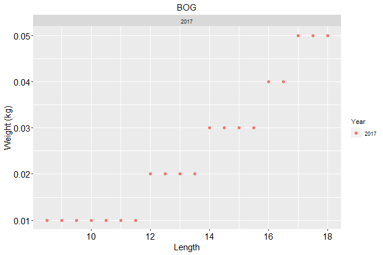

```r
check_lw_TaskVII.2(task_vii2, MS = "ITA", GSA = "18", SP = "BOG")
```

## Task VII.3.1 table

### Check empty fields in GFCM Task VII.3.1 table

The function `check_EF_TaskVII31` checks the presence of not allowed empty data in the given table, according to the GFCM Data Collection Reference Framework (DCRF, V. 20.1). The function returns two lists. The first list gives the number of NA for each reference column.

```r
check_EF_TaskVII31(task_vii31, verbose=FALSE)[[1]]
```

```
#> Reference_Year            CPC            GSA        Species            Sex
#>              0              0              0              0              0
#>            L50
#>              0
```

The second list returns the index of each NA in the reference column.

```r
check_EF_TaskVII31(task_vii31, verbose=FALSE)[[2]]
```

```
#> $Reference_Year
#> integer(0)
#>
#> $CPC
#> integer(0)
#>
#> $GSA
#> integer(0)
#>
#> $Species
#> integer(0)
#>
#> $Sex
#> integer(0)
#>
#> $L50
#> integer(0)
```

### Comparison between min/max L50 observed for each species and sex with theoretical values

The function `check_minmaxl50_TaskVII.3.1` allows to verify the consistency of L50 reported in the TaskVII.3.1 table with the theoretical values reported in the minmaxLtaskVII31 table. The function allows to identify the records in which the observed L50 are greater or lower than the expected ones. The function returns a table with the comparison between min/max L50 observed for each species and sex with theoretical values. The field check_max of the returned data frame will contain “Warning” in case of L50 outliers.

```r
check_minmaxl50_TaskVII.3.1(task_vii31,minmaxLtaskVII31,MS="ITA",GSA="19")
```

```
#>   Species Sex min_observed max_observed min_theoretical max_theoretical
#> 1     HKE   F         33.6         33.6               5             100
#> 2     HKE   M         17.8         17.8               5             100
#> 3     MTS   F         20.3         20.3               5             100
#> 4     MUT   F         11.4         11.4               5             100
#> 5     MUT   M         10.4         10.4               5             100
#>   check_min check_max
#> 1
#> 2
#> 3
#> 4
#> 5
```

### Check duplicated records in GFCM Task VII.3.1 table

The function `check_RD_taskVII31` checks the presence of duplicated records. In particular, it checks whether the combination of the first 5 columns generates duplicate records. The function returns the indices of the duplicated rows, checking the unique combinations of the first 5 columns of the Task VII.3.1 table.

```r
check_RD_taskVII31(task_vii31)
```

```
#> no duplicated lines in the data frame
#> integer(0)
```